# Prediction of payment on real credit risk dataset using KNN, decision trees, random forests, bagging and gradient boosting for best model comparison

Nicola Rosca

2024-01-19

## Introduction

This report is done by Nicola Rosca alone. It represents the use of various models to predict a credit card defaulting. The response was binary, where 0 was represented by No and 1 was Yes.

The data set provided had 23 variables that are computed in all models. Throughout the coursework, the Y variable has been renamed as Pay.result and mutated into a factor.

The remaining variables represented amount of credit given, gender, education, marital status, age, history of past payments, and bill statements.

The data was already split into a train and a test set, however the train set was further split into validation set.

The aim of this coursework is to identify the best model for a classification problem, where the focus is on the accuracy, sensitivity and specificity of each model.

This analysis can be further used for the medical and environmental industries, as well as business.

## Methodology

The first part of this coursework represented the exploratory data analysis, data pre-processing and normalization.

The models used in this coursework, are k-Nearest Neighbor, Decision Trees, Random Forests, Bagging and Gradient Boosting.

### K-Nearest Neighbor

k-Nearest Neighbor is a non-parametric method, because it does not assume a parametric form for f(x) and therefore tends to be more flexible in understanding trend data (James et al., 2022). In simpler words, KNN is an algorithm where “each observation is predicted based on its similarity to other observation” (James et al., 2022). KNN is a memory-based algorithm and uses the caret package. For classification, KNN looks at the most common class based on the given k. In order to be able to use KNN on the given sets, I normalized all three data sets through a normalization function.

### Decision Trees

According to “HANDS ON MACHINE LEARNING WITH R”, “a basic decision tree partitions the training data into groups with similar response values and then fits a simple constant in each subgroup”. In the case of our classification problem, the possibilities predicted with the decision tree models, have used a part of each within the subgroups. The visualizations show that if unpruned, the general tree that included all the variables was severely overfitting (the labels and leaves were overlapping, regardless of panel and text size). Therefore, I pruned the tree that included all possible variables, including X6, through multiple hyper parameters. Pruning is defined as growing an overly complex tree and then using hyper parameters to find an optimal sub tree. (B.B.& B., 2020)

The one I found was trimmed down using the cp (complexity parameter), min split (minimum split) and max depth hyper parameters (maximum depth). Cutting down branches using this pruning technique found the perfect balance where a model captured the trend or patterns in data, but did not consider the noise data. (B.B.& B., 2020)

### Bagging

Bagging is an aggregation of bootstrap samples, which draws samples with the replacement of the initial train data. Bagging helps minimize overfitting, as it is designed to improve stability and accuracy in a classification problem. (B.B.& B., 2020)

In Bagging, b bootstrap samples of the train_data (training data set used in this coursework) are created and used with the classification algorithm, in this case called base learner. The algorithm is applied to each bootstrap sample and the predictions are reported using the plurality vote or by averaging the estimated class probabilities.

According to B.B.& B. (2020), the idea of bagging is also known as the “wisdom of the crowd”, and “essentially means that the aggregation of information in large diverse groups results in decisions that are often better than could have been made by any single member of the group. The more diverse the group members are then the more diverse their perspectives and predictions will be, which often leads to better aggregated information”.

### Random Forests

Random forests algorithms use the same principles as decision trees. It builds many trees on bootstrapped samples of the train_data. The reason random forests are quite popular is that their output is “out-of-the-box”, meaning “the default values tend to produce good results”. In comparison to other machine learning algorithms, they have the least variability in accuracy when tuned. (B.B.& B., 2020)

The rule of sampling for random forests is that 100% of the train_data is observed and replicated in the samples. However, the downside of these models is that they are computationally inefficient, resulting in a loss of time depending on the data and parameters used. In the example of this coursework, running the default random forests algorithms took roughly 5 minutes per model. (B.B.& B., 2020)

### Gradient boosting

Gradient boosting models have been proven successful across many industries, because “build an ensemble of shallow trees in sequence with each tree learning and improving on the previous one”. According to “HANDS ON MACHINE LEARNING WITH R” (2020), GBMs are considered gradient descent algorithms, which are generic optimization algorithms that find the best solutions for multiple issues.

Gradient boosting combines predictions from weak learners, and improves their performance by updating the weights based one errors from previous iterations, until the model accuracy is improved. (A. and Vidhya, 2024)

### Grid search functions // Decision trees, random forests & gradient boosting

In this coursework, I chose to apply a grid search function for all of the above algorithm, in order to be able to identify the best model, based on a series of parameters. (R. and Vidhya, 2023)

Grid searches are used to identify the best hyper parameters values to get the correct predictions without having to apply a manual search method. Grid search “uses a different combination of all the specified hyper parameters and their values and calculates the performance for each combination and selects the best value for the hyper parameters. This makes the processing time-consuming and expensive based on the number of hyper parameters involved”. (R. and Vidhya, 2023)

### Variable selection

The variable selection in this coursework was performed through the computation of the p value and an ols model, used to find the best combination of variables for prediction.

## EDA

```r
summary(credit_train)
```

```
##        Y                X1               X2              X3
##  Min.   :0.0000   Min.   : 10000   Min.   :1.000   Min.   :0.00
##  1st Qu.:0.0000   1st Qu.: 50000   1st Qu.:1.000   1st Qu.:1.00
##  Median :0.0000   Median :140000   Median :2.000   Median :2.00
##  Mean   :0.2212   Mean   :167450   Mean   :1.605   Mean   :1.85
##  3rd Qu.:0.0000   3rd Qu.:240000   3rd Qu.:2.000   3rd Qu.:2.00
##  Max.   :1.0000   Max.   :800000   Max.   :2.000   Max.   :6.00
##        X4              X5              X6                 X7
##  Min.   :0.000   Min.   :21.00   Min.   :-2.00000   Min.   :-2.0000
##  1st Qu.:1.000   1st Qu.:28.00   1st Qu.:-1.00000   1st Qu.:-1.0000
##  Median :2.000   Median :34.00   Median : 0.00000   Median : 0.0000
##  Mean   :1.556   Mean   :35.37   Mean   :-0.02047   Mean   :-0.1309
##  3rd Qu.:2.000   3rd Qu.:41.00   3rd Qu.: 0.00000   3rd Qu.: 0.0000
##  Max.   :3.000   Max.   :75.00   Max.   : 8.00000   Max.   : 8.0000
##        X8               X9               X10               X11
##  Min.   :-2.000   Min.   :-2.0000   Min.   :-2.0000   Min.   :-2.0000
##  1st Qu.:-1.000   1st Qu.:-1.0000   1st Qu.:-1.0000   1st Qu.:-1.0000
##  Median : 0.000   Median : 0.0000   Median : 0.0000   Median : 0.0000
##  Mean   :-0.163   Mean   :-0.2145   Mean   :-0.2569   Mean   :-0.2833
##  3rd Qu.: 0.000   3rd Qu.: 0.0000   3rd Qu.: 0.0000   3rd Qu.: 0.0000
##  Max.   : 8.000   Max.   : 8.0000   Max.   : 7.0000   Max.   : 7.0000
##       X12              X13              X14              X15
##  Min.   :-10682   Min.   :-67526   Min.   :-34041   Min.   :-170000
##  1st Qu.:  3672   1st Qu.:  3034   1st Qu.:  2734   1st Qu.:   2393
##  Median : 23048   Median : 21521   Median : 20165   Median :  19091
##  Mean   : 51641   Mean   : 49457   Mean   : 47118   Mean   :  43077
##  3rd Qu.: 67939   3rd Qu.: 64322   3rd Qu.: 60263   3rd Qu.:  54600
##  Max.   :746814   Max.   :671563   Max.   :855086   Max.   : 706864
##       X16              X17               X18              X19
##  Min.   :-46627   Min.   :-339603   Min.   :     0   Min.   :      0
##  1st Qu.:  1800   1st Qu.:   1200   1st Qu.:  1000   1st Qu.:    833
##  Median : 18178   Median :  17177   Median :  2113   Median :   2014
##  Mean   : 40273   Mean   :  38709   Mean   :  5616   Mean   :   5822
##  3rd Qu.: 50135   3rd Qu.:  49123   3rd Qu.:  5023   3rd Qu.:   5000
##  Max.   :587067   Max.   : 568638   Max.   :493358   Max.   :1227082
##       X20              X21              X22              X23
##  Min.   :     0   Min.   :     0   Min.   :     0   Min.   :     0
##  1st Qu.:   390   1st Qu.:   290   1st Qu.:   204   1st Qu.:    80
##  Median :  1809   Median :  1500   Median :  1500   Median :  1500
##  Mean   :  4943   Mean   :  4997   Mean   :  4798   Mean   :  5226
##  3rd Qu.:  4572   3rd Qu.:  4048   3rd Qu.:  4020   3rd Qu.:  4000
##  Max.   :380478   Max.   :528897   Max.   :426529   Max.   :528666
```

```r
summary(credit_test)
```

```
##        Y                X1                X2              X3
##  Min.   :0.0000   Min.   :  10000   Min.   :1.000   Min.   :0.000
##  1st Qu.:0.0000   1st Qu.:  50000   1st Qu.:1.000   1st Qu.:1.000
##  Median :0.0000   Median : 140000   Median :2.000   Median :2.000
##  Mean   :0.2212   Mean   : 167518   Mean   :1.603   Mean   :1.856
##  3rd Qu.:0.0000   3rd Qu.: 240000   3rd Qu.:2.000   3rd Qu.:2.000
##  Max.   :1.0000   Max.   :1000000   Max.   :2.000   Max.   :6.000
##        X4              X5             X6                 X7
##  Min.   :0.000   Min.   :21.0   Min.   :-2.00000   Min.   :-2.0000
##  1st Qu.:1.000   1st Qu.:28.0   1st Qu.:-1.00000   1st Qu.:-1.0000
##  Median :2.000   Median :34.0   Median : 0.00000   Median : 0.0000
##  Mean   :1.548   Mean   :35.6   Mean   :-0.01293   Mean   :-0.1366
##  3rd Qu.:2.000   3rd Qu.:41.0   3rd Qu.: 0.00000   3rd Qu.: 0.0000
##  Max.   :3.000   Max.   :79.0   Max.   : 8.00000   Max.   : 7.0000
##        X8                X9               X10               X11
##  Min.   :-2.0000   Min.   :-2.0000   Min.   :-2.0000   Min.   :-2.0000
##  1st Qu.:-1.0000   1st Qu.:-1.0000   1st Qu.:-1.0000   1st Qu.:-1.0000
##  Median : 0.0000   Median : 0.0000   Median : 0.0000   Median : 0.0000
##  Mean   :-0.1694   Mean   :-0.2269   Mean   :-0.2755   Mean   :-0.2989
##  3rd Qu.: 0.0000   3rd Qu.: 0.0000   3rd Qu.: 0.0000   3rd Qu.: 0.0000
##  Max.   : 8.0000   Max.   : 8.0000   Max.   : 8.0000   Max.   : 8.0000
##       X12               X13              X14               X15
##  Min.   :-165580   Min.   :-69777   Min.   :-157264   Min.   :-50616
##  1st Qu.:   3472   1st Qu.:  2944   1st Qu.:   2639   1st Qu.:  2290
##  Median :  21688   Median : 20926   Median :  20041   Median : 19013
##  Mean   :  50806   Mean   : 48901   Mean   :  46909   Mean   : 43449
##  3rd Qu.:  66207   3rd Qu.: 63769   3rd Qu.:  60007   3rd Qu.: 54407
##  Max.   : 964511   Max.   :983931   Max.   :1664089   Max.   :891586
##       X16              X17               X18                X19
##  Min.   :-81334   Min.   :-150953   Min.   :     0.0   Min.   :      0.0
##  1st Qu.:  1730   1st Qu.:   1308   1st Qu.:   980.8   1st Qu.:    832.8
##  Median : 18025   Median :  16924   Median :  2100.0   Median :   2004.0
##  Mean   : 40350   Mean   :  39035   Mean   :  5711.2   Mean   :   6020.3
##  3rd Qu.: 50247   3rd Qu.:  49327   3rd Qu.:  5001.0   3rd Qu.:   5000.0
##  Max.   :927171   Max.   : 961664   Max.   :873552.0   Max.   :1684259.0
##       X20                X21              X22                X23
##  Min.   :     0.0   Min.   :     0   Min.   :     0.0   Min.   :     0.0
##  1st Qu.:   390.8   1st Qu.:   300   1st Qu.:   286.8   1st Qu.:   156.8
##  Median :  1800.0   Median :  1500   Median :  1519.0   Median :  1500.0
##  Mean   :  5508.4   Mean   :  4655   Mean   :  4800.3   Mean   :  5204.6
##  3rd Qu.:  4500.0   3rd Qu.:  4002   3rd Qu.:  4041.2   3rd Qu.:  4007.0
##  Max.   :896040.0   Max.   :621000   Max.   :417990.0   Max.   :527143.0
```

```r
str(credit_train)
```

```
## 'data.frame':    15000 obs. of  24 variables:
##  $ Y  : int  1 0 0 0 0 0 0 1 0 1 ...
##  $ X1 : int  20000 50000 50000 50000 500000 100000 630000 70000 130000 450000 ...
##  $ X2 : int  2 2 1 1 1 2 2 1 2 2 ...
##  $ X3 : int  2 2 2 1 1 2 2 2 3 1 ...
##  $ X4 : int  1 1 1 2 2 2 2 2 2 1 ...
##  $ X5 : int  24 37 57 37 29 23 41 30 39 40 ...
##  $ X6 : int  2 0 -1 0 0 0 -1 1 0 -2 ...
##  $ X7 : int  2 0 0 0 0 -1 0 2 0 -2 ...
##  $ X8 : int  -1 0 -1 0 0 -1 -1 2 0 -2 ...
##  $ X9 : int  -1 0 0 0 0 0 -1 0 0 -2 ...
##  $ X10: int  -2 0 0 0 0 0 -1 0 0 -2 ...
##  $ X11: int  -2 0 0 0 0 -1 -1 2 -1 -2 ...
##  $ X12: int  3913 46990 8617 64400 367965 11876 12137 65802 38358 5512 ...
##  $ X13: int  3102 48233 5670 57069 412023 380 6500 67369 27688 19420 ...
##  $ X14: int  689 49291 35835 57608 445007 601 6500 65701 24489 1473 ...
##  $ X15: int  0 28314 20940 19394 542653 221 6500 66782 20616 560 ...
##  $ X16: int  0 28959 19146 19619 483003 -159 6500 36137 11802 0 ...
##  $ X17: int  0 29547 19131 20024 473944 567 2870 36894 930 0 ...
##  $ X18: int  0 2000 2000 2500 55000 380 1000 3200 3000 19428 ...
##  $ X19: int  689 2019 36681 1815 40000 601 6500 0 1537 1473 ...
##  $ X20: int  0 1200 10000 657 38000 0 6500 3000 1000 560 ...
##  $ X21: int  0 1100 9000 1000 20239 581 6500 3000 2000 0 ...
##  $ X22: int  0 1069 689 1000 13750 1687 2870 1500 930 0 ...
##  $ X23: int  0 1000 679 800 13770 1542 0 0 33764 1128 ...
```

```r
str(credit_test)
```

```
## 'data.frame':    15000 obs. of  24 variables:
##  $ Y  : int  1 0 0 0 0 0 0 0 1 0 ...
##  $ X1 : int  120000 90000 140000 20000 200000 260000 250000 50000 20000 320000 ...
##  $ X2 : int  2 2 2 1 2 2 1 2 1 1 ...
##  $ X3 : int  2 2 3 3 3 1 1 3 1 1 ...
##  $ X4 : int  2 2 1 2 2 2 2 3 2 1 ...
##  $ X5 : int  26 34 28 35 34 51 29 23 24 49 ...
##  $ X6 : int  -1 0 0 -2 0 -1 0 1 0 0 ...
##  $ X7 : int  2 0 0 -2 0 -1 0 2 0 0 ...
##  $ X8 : int  0 0 2 -2 2 -1 0 0 2 0 ...
##  $ X9 : int  0 0 0 -2 0 -1 0 0 2 -1 ...
##  $ X10: int  0 0 0 -1 0 -1 0 0 2 -1 ...
##  $ X11: int  2 0 0 -1 -1 2 0 0 2 -1 ...
##  $ X12: int  2682 29239 11285 0 11073 12261 70887 50614 15376 253286 ...
##  $ X13: int  1725 14027 14096 0 9787 21670 67060 29173 18010 246536 ...
##  $ X14: int  2682 13559 12108 0 5535 9966 63561 28116 17428 194663 ...
##  $ X15: int  3272 14331 12211 0 2513 8517 59696 28771 18338 70074 ...
##  $ X16: int  3455 14948 11793 13007 1828 22287 56875 29531 17905 5856 ...
##  $ X17: int  3261 15549 3719 13912 3731 13668 55512 30211 19104 195599 ...
##  $ X18: int  0 1518 3329 0 2306 21818 3000 0 3200 10358 ...
##  $ X19: int  1000 1500 0 0 12 9966 3000 1500 0 10000 ...
##  $ X20: int  1000 1000 432 0 50 8583 3000 1100 1500 75940 ...
##  $ X21: int  1000 1000 1000 13007 300 22301 3000 1200 0 20000 ...
##  $ X22: int  0 1000 1000 1122 3738 0 3000 1300 1650 195599 ...
##  $ X23: int  2000 5000 1000 0 66 3640 3000 1100 0 50000 ...
```

```r
dim(credit_train)
```

```
## [1] 15000    24
```

```r
dim(credit_test)
```

```
## [1] 15000    24
```

```r
sapply(credit_train, mean, na.rm = TRUE)
```

```
##               Y              X1              X2              X3              X4
##      0.22120000 167450.24533333      1.60486667      1.85000000      1.55620000
##              X5              X6              X7              X8              X9
##     35.36793333     -0.02046667     -0.13093333     -0.16300000     -0.21446667
##             X10             X11             X12             X13             X14
##     -0.25693333     -0.28326667  51640.51280000  49456.84326667  47117.56206667
##             X15             X16             X17             X18             X19
##  43077.44566667  40272.92266667  38708.68586667   5615.96000000   5822.05853333
##             X20             X21             X22             X23
##   4942.95900000   4997.32886667   4798.47840000   5226.42126667
```

```r
sapply(credit_train, sd, na.rm = TRUE)
```

```
##              Y             X1             X2             X3             X4
##      0.4150687 130109.9250229      0.4888956      0.7866858      0.5227426
##             X5             X6             X7             X8             X9
##      9.1541181      1.1250476      1.1984513      1.2026058      1.1805777
##            X10            X11            X12            X13            X14
##      1.1486542      1.1596765  73618.9438515  71335.8211189  69182.4349401
##            X15            X16            X17            X18            X19
##  64016.9077858  60503.3393544  59212.4254097  15551.7080283  21556.7485675
##            X20            X21            X22            X23
##  13629.0347364  16499.3495115  15463.9484847  18099.8519478
```

```r
sapply(credit_test, mean, na.rm = TRUE)
```

```
##               Y              X1              X2              X3              X4
##      0.22120000 167518.40000000      1.60260000      1.85626667      1.54753333
##              X5              X6              X7              X8              X9
##     35.60306667     -0.01293333     -0.13660000     -0.16940000     -0.22686667
##             X10             X11             X12             X13             X14
##     -0.27546667     -0.29893333  50806.14900000  48901.30706667  46908.74753333
##             X15             X16             X17             X18             X19
##  43448.45226667  40349.87926667  39034.83493333   5711.20100000   6020.26846667
##             X20             X21             X22             X23
##   5508.40400000   4654.82486667   4800.29686667   5204.58386667
```

```r
sapply(credit_test, sd, na.rm = TRUE)
```

```
##              Y             X1             X2             X3             X4
##      0.4150687 129388.7121198      0.4893763      0.7940085      0.5211769
##             X5             X6             X7             X8             X9
##      9.2800675      1.1225789      1.1959525      1.1911332      1.1575927
##            X10            X11            X12            X13            X14
##      1.1174680      1.1402012  73652.8643956  71012.6380752  69518.0883615
##            X15            X16            X17            X18            X19
##  64648.8621672  61091.5517986  59895.3704206  17516.9245175  24435.3383144
##            X20            X21            X22            X23
##  20835.5559142  14784.6640996  15090.8948467  17449.7212136
```

```r
sum(is.na(credit_train))
```

```
## [1] 0
```

```r
sum(is.na(credit_test))
```

```
## [1] 0
```

```r
cor(credit_train, use = "complete.obs")
```

```
##                Y          X1           X2          X3           X4          X5
## Y    1.000000000 -0.15929622 -0.038751691  0.03832486 -0.024419782  0.01100539
## X1  -0.159296222  1.00000000  0.018178519 -0.22436429 -0.110905862  0.14903142
## X2  -0.038751691  0.01817852  1.000000000  0.01403257 -0.031931870 -0.08558835
## X3   0.038324865 -0.22436429  0.014032566  1.00000000 -0.144542053  0.17395751
## X4  -0.024419782 -0.11090586 -0.031931870 -0.14454205  1.000000000 -0.41631650
## X5   0.011005386  0.14903142 -0.085588353  0.17395751 -0.416316504  1.00000000
## X6   0.331649129 -0.27820926 -0.061492279  0.11314124  0.015389682 -0.03565077
## X7   0.268785768 -0.30297060 -0.073171240  0.12611442  0.025687685 -0.04981072
## X8   0.234251764 -0.29050317 -0.060791782  0.11488604  0.037957636 -0.06387684
## X9   0.221039392 -0.27409489 -0.068284201  0.11618260  0.031253366 -0.05101506
## X10  0.211087669 -0.25346699 -0.060054939  0.10513116  0.035375224 -0.05522038
## X11  0.192511974 -0.23893978 -0.048674636  0.08876682  0.028517083 -0.04845076
## X12 -0.018290262  0.27855454 -0.028710959  0.02470422 -0.022735951  0.05109841
## X13 -0.010793754  0.26995013 -0.027314040  0.01862432 -0.018700360  0.04806298
## X14 -0.010390339  0.27183495 -0.021815426  0.01522065 -0.023329896  0.04851635
## X15 -0.005165812  0.27888335 -0.020543558 -0.00351130 -0.023648010  0.04546646
## X16 -0.003686868  0.28578167 -0.015920980 -0.01250060 -0.026416930  0.04392872
## X17 -0.001678646  0.27649513 -0.017369809 -0.01183624 -0.023732193  0.04176913
## X18 -0.074303425  0.20745306 -0.005196589 -0.03799282 -0.008444832  0.02534070
## X19 -0.063889415  0.18021740 -0.002762414 -0.02712522 -0.014977296  0.02527108
## X20 -0.069626662  0.23192215 -0.007414207 -0.05226226 -0.011987607  0.03166095
## X21 -0.056760320  0.20205007 -0.001891619 -0.03819148 -0.014952668  0.01748028
## X22 -0.054227166  0.21579958 -0.004295357 -0.03447517 -0.011910363  0.03060397
## X23 -0.053284262  0.22665540 -0.006882310 -0.03372930 -0.007698541  0.01958739
##              X6          X7           X8           X9          X10          X11
## Y    0.33164913  0.26878577  0.234251764  0.221039392  0.211087669  0.192511974
## X1  -0.27820926 -0.30297060 -0.290503165 -0.274094892 -0.253466992 -0.238939781
## X2  -0.06149228 -0.07317124 -0.060791782 -0.068284201 -0.060054939 -0.048674636
## X3   0.11314124  0.12611442  0.114886045  0.116182600  0.105131155  0.088766819
## X4   0.01538968  0.02568769  0.037957636  0.031253366  0.035375224  0.028517083
## X5  -0.03565077 -0.04981072 -0.063876840 -0.051015064 -0.055220382 -0.048450762
## X6   1.00000000  0.67668252  0.581958313  0.543333365  0.512205868  0.477490214
## X7   0.67668252  1.00000000  0.766871639  0.661487129  0.624252237  0.574582729
## X8   0.58195831  0.76687164  1.000000000  0.774291295  0.686162325  0.630956242
## X9   0.54333336  0.66148713  0.774291295  1.000000000  0.819450745  0.720757935
## X10  0.51220587  0.62425224  0.686162325  0.819450745  1.000000000  0.820898616
## X11  0.47749021  0.57458273  0.630956242  0.720757935  0.820898616  1.000000000
## X12  0.18622329  0.23246885  0.209237842  0.203797430  0.202224626  0.206232188
## X13  0.18919889  0.23355185  0.237972742  0.226090672  0.221380327  0.224650947
```

[output cut: 70 more lines]

```
## X9  -0.021312943
## X10 -0.018830645
## X11 -0.025893851
## X12  0.193657365
## X13  0.187494416
## X14  0.201074668
## X15  0.182007416
## X16  0.169340128
## X17  0.100810237
## X18  0.203518309
## X19  0.177668334
## X20  0.142465416
## X21  0.150299191
## X22  0.157176557
## X23  1.000000000
```

```r
cor(credit_test, use = "complete.obs")
```

```
##                Y          X1            X2           X3           X4
## Y    1.000000000 -0.14771253 -0.0411685011  0.017783490 -0.024260142
## X1  -0.147712533  1.00000000  0.0313637337 -0.213993911 -0.105352473
## X2  -0.041168501  0.03136373  1.0000000000  0.014448094 -0.030885687
## X3   0.017783490 -0.21399391  0.0144480944  1.000000000 -0.142345218
## X4  -0.024260142 -0.10535247 -0.0308856867 -0.142345218  1.000000000
## X5   0.016738023  0.14045914 -0.0960421933  0.176070533 -0.411959451
## X6   0.317927297 -0.26417056 -0.0537743639  0.097621329  0.024525691
## X7   0.258307463 -0.28974437 -0.0683800321  0.117074407  0.022665273
## X8   0.236270022 -0.28167774 -0.0714612877  0.113197429  0.027309150
## X9   0.212127298 -0.26067395 -0.0519426665  0.101397039  0.034949056
## X10  0.197069558 -0.24526257 -0.0499923614  0.089875794  0.035763435
## X11  0.181146578 -0.23138097 -0.0393035713  0.075889020  0.040181229
## X12 -0.020998140  0.29235511 -0.0385931667  0.022515296 -0.024306164
## X13 -0.017608443  0.28676991 -0.0350856963  0.018904974 -0.024592047
## X14 -0.017743018  0.29465392 -0.0273024785  0.010827368 -0.026513233
## X15 -0.015098723  0.30904592 -0.0231888710  0.002528095 -0.022996787
## X16 -0.009804627  0.30531975 -0.0180753857 -0.002730075 -0.024368972
## X17 -0.009024083  0.30422265 -0.0160923807 -0.006439546 -0.018660192
## X18 -0.071953167  0.18504361  0.0041633523 -0.037112005 -0.003759423
## X19 -0.054110391  0.17752256 -0.0001684479 -0.032711676 -0.001965418
## X20 -0.049525165  0.20363899 -0.0096143000 -0.033434889  0.002096095
## X21 -0.057089941  0.20519565 -0.0026662305 -0.038303825 -0.010325471
## X22 -0.056050342  0.21866756  0.0010233557 -0.046344228  0.009799230
## X23 -0.053096796  0.21228585  0.0014955257 -0.040782095 -0.005553429
##              X5          X6          X7           X8           X9          X10
## Y    0.01673802  0.31792730  0.25830746  0.236270022  0.212127298  0.197069558
## X1   0.14045914 -0.26417056 -0.28974437 -0.281677738 -0.260673950 -0.245262575
## X2  -0.09604219 -0.05377436 -0.06838003 -0.071461288 -0.051942667 -0.049992361
## X3   0.17607053  0.09762133  0.11707441  0.113197429  0.101397039  0.089875794
## X4  -0.41195945  0.02452569  0.02266527  0.027309150  0.034949056  0.035763435
## X5   1.00000000 -0.04329501 -0.05043241 -0.042212190 -0.048308155 -0.052237419
## X6  -0.04329501  1.00000000  0.66765409  0.566476987  0.534347531  0.506741367
## X7  -0.05043241  0.66765409  1.00000000  0.766235909  0.662708757  0.621372784
## X8  -0.04221219  0.56647699  0.76623591  1.000000000  0.780536558  0.687473370
## X9  -0.04830816  0.53434753  0.66270876  0.780536558  1.000000000  0.820242368
## X10 -0.05223742  0.50674137  0.62137278  0.687473370  0.820242368  1.000000000
## X11 -0.04894472  0.47165897  0.57646632  0.634463449  0.711962575  0.812724019
## X12  0.06146339  0.18796150  0.23729054  0.207683992  0.201779988  0.211233454
## X13  0.06055988  0.19055535  0.23696011  0.236592529  0.225516311  0.232611014
```

[output cut: 70 more lines]

```
## X9  -0.033426049 -0.032130522
## X10 -0.030718685 -0.027514572
## X11 -0.043452642 -0.024684464
## X12  0.155723347  0.164559804
## X13  0.142106299  0.160505722
## X14  0.191556946  0.163050689
## X15  0.166634072  0.173250120
## X16  0.145673446  0.158978099
## X17  0.305189006  0.130623339
## X18  0.154789845  0.170442159
## X19  0.236491063  0.140297030
## X20  0.178227366  0.183575210
## X21  0.177792501  0.166788294
## X22  1.000000000  0.152477056
## X23  0.152477056  1.000000000
```

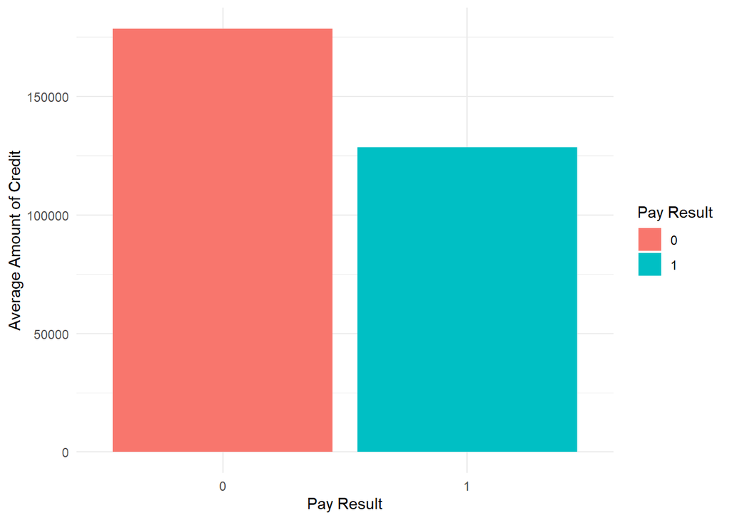

```r
credit_train_avg <- credit_train %>%
  group_by(Y) %>%
  summarise(Average_X1 = mean(X1, na.rm = TRUE))

ggplot(credit_train_avg, aes(x = factor(Y), y = Average_X1, fill = factor(Y))) +
  geom_bar(stat = "identity", position = "dodge") +
  labs(x = "Pay Result", y = "Average Amount of Credit", fill = "Pay Result") +
  theme_minimal()
```

*Fig 1. Y and amount of credit (average amount)*

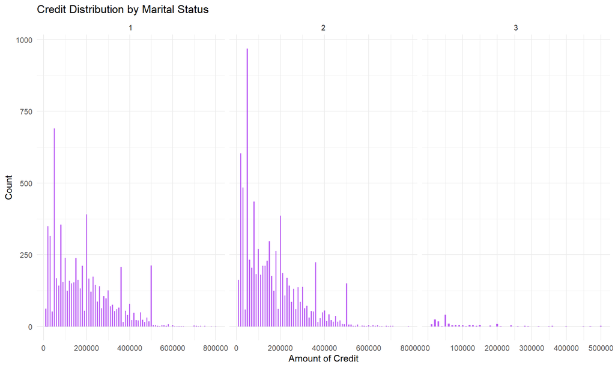

```r
credit_train_filtered <- credit_train %>%
  filter(X4 %in% c(1, 2, 3))

# Now, plot the data
ggplot(credit_train_filtered, aes(x = X1)) +
  geom_histogram(binwidth = 5000, fill = "purple", alpha = 0.7) + # Adjust binwidth as needed
  facet_wrap(~ X4, scales = "free_x") +
  labs(x = "Amount of Credit", y = "Count") +
  theme_minimal() +
  ggtitle("Credit Distribution by Marital Status")
```

```r
percentage_distribution <- credit_train %>%
  group_by(Y) %>%
  summarise(percentage = n() / nrow(credit_train) * 100)
percentage_distribution
```

```
## # A tibble: 2 × 2
##       Y percentage
##   <int>      <dbl>
## 1     0       77.9
## 2     1       22.1
```

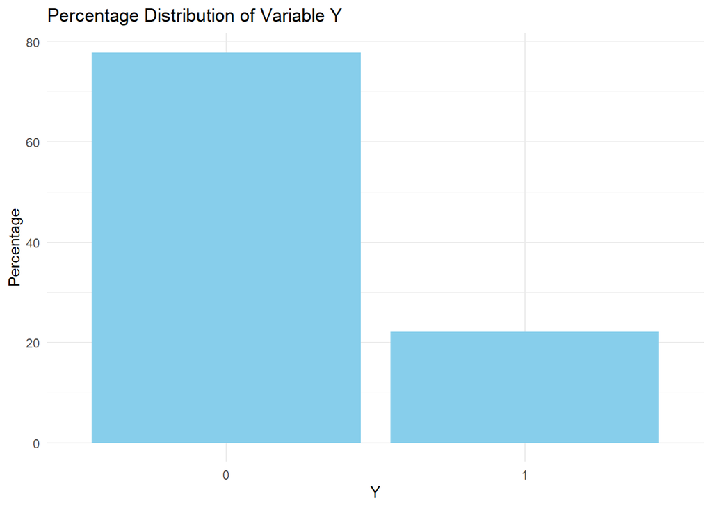

```r
ggplot(percentage_distribution, aes(x = as.factor(Y), y = percentage)) +
  geom_bar(stat = "identity", fill = "skyblue", orientation = 'h') +
  labs(title = "Percentage Distribution of Variable Y", x = "Y", y = "Percentage") +
  theme_minimal() +
  theme(legend.position = "bottom") +
  guides(fill = guide_legend(title = "Categories"))
```

*Fig 3. Percentage distribution of variable Y*

This graph represents another visualization of the data unbalance, this time with a percentage, where 0 is represented as a majority class.

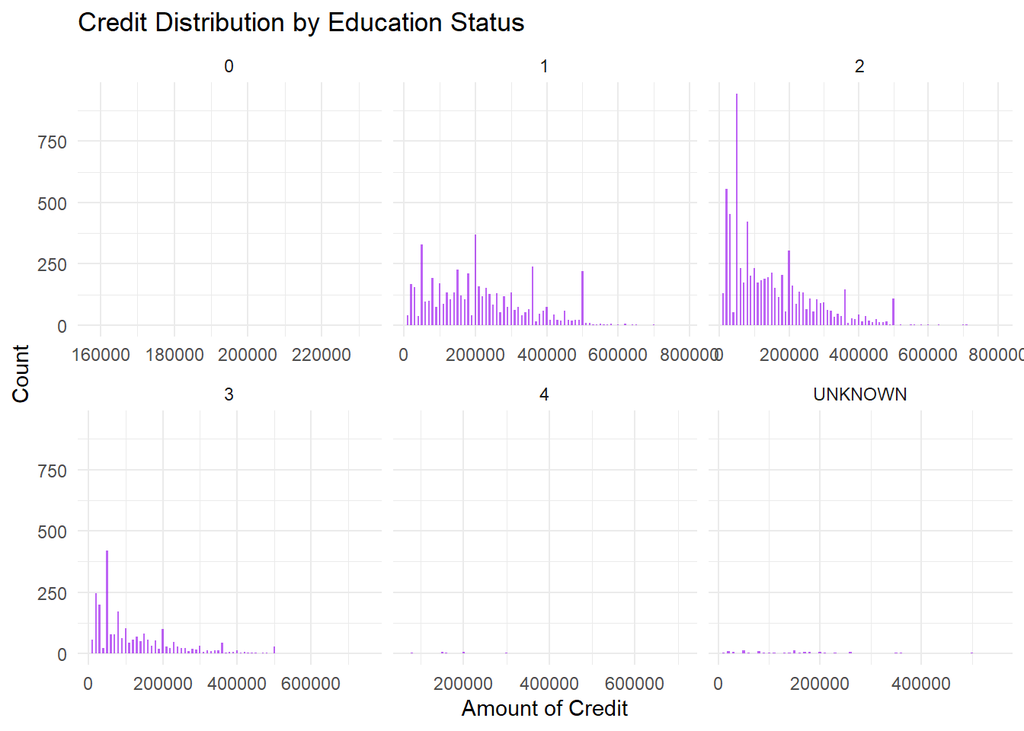

```r
credit_train_alteredX4 <- credit_train %>%
  mutate(X3 = case_when(
    X3 == 5 ~ "UNKNOWN",
    X3 == 6 ~ "UNKNOWN",
    TRUE ~ as.character(X3)
  ))


ggplot(credit_train_alteredX4, aes(x = X1)) +
  geom_histogram(binwidth = 5000, fill = "purple", alpha = 0.7, nrow=2, ncol=2) + # Adjust binwidth as needed
  facet_wrap(~ X3, scales = "free_x") +
  labs(x = "Amount of Credit", y = "Count") +
  theme_minimal() +
  ggtitle("Credit Distribution by Education Status")
```

Even though the data dictionary shows only four categories, the grid shows 6, therefore I combined the remaining unknown categories into one “unknown”. Regardless, this shows that individuals who go to university are borrowing more money.

### Data split

```r
split_index <- floor(0.2 * nrow(credit_train))

# create a random sample of row indices
sampled_indices <- sample(seq_len(nrow(credit_train)), size = split_index)

# split the dataframe
val_set <- credit_train[sampled_indices, ]
train_set <- credit_train[-sampled_indices, ]

#PRE-PROCESS DATA

#preprocess train data
train_data <- train_set %>%
  rename(Pay.result = Y, Credit.value = X1) %>%
  mutate(Pay.result = as.factor(Pay.result))

#preprocess test data
test_data <- credit_test %>%
  rename(Pay.result = Y, Credit.value = X1) %>%
  mutate(Pay.result = as.factor(Pay.result))

#preprocess validation data
val_data <- val_set %>%
  rename(Pay.result = Y, Credit.value = X1) %>%
  mutate(Pay.result = as.factor(Pay.result))
```

### Normalisation of train data

```r
numeric_columns <- c("X2", "X3", "X4", "X5", "X7", "X8", "X9", "X11", "X12", "X13", "X14", "X15", "X16", "X17", "X18", "X19", "X20", "X21", "X22", "X23")

# NORMALISATION FUNCTION
make_normal <- function(x) {
  return ((x - min(x)) / (max(x) - min(x)))
}

# NORMALISATION OF TRAIN DATA
train_normalised <- train_data
train_normalised[numeric_columns] <- lapply(train_data[numeric_columns], make_normal)

head(train_normalised)
```

```
##   Pay.result Credit.value X2        X3        X4         X5 X6  X7  X8  X9 X10
## 2          0        50000  1 0.3333333 0.3333333 0.29629630  0 0.2 0.2 0.2   0
## 3          0        50000  0 0.3333333 0.3333333 0.66666667 -1 0.2 0.1 0.2   0
## 4          0        50000  0 0.1666667 0.6666667 0.29629630  0 0.2 0.2 0.2   0
## 5          0       500000  0 0.1666667 0.6666667 0.14814815  0 0.2 0.2 0.2   0
## 6          0       100000  1 0.3333333 0.6666667 0.03703704  0 0.1 0.1 0.2   0
## 7          0       630000  1 0.3333333 0.6666667 0.37037037 -1 0.2 0.1 0.1  -1
##         X11        X12        X13        X14       X15        X16       X17
## 2 0.2222222 0.08470046 0.11151244 0.09372339 0.2261628 0.12714064 0.4256244
## 3 0.2222222 0.02674894 0.05084362 0.07858945 0.2177533 0.11063453 0.4136149
## 4 0.2222222 0.11099331 0.12410717 0.10307751 0.2159902 0.11143014 0.4146445
## 5 0.2222222 0.56944199 0.63005461 0.53878467 0.8127292 0.89087261 0.9380075
## 6 0.1111111 0.03167074 0.04330331 0.03896181 0.1941247 0.07816224 0.3922109
## 7 0.1111111 0.03206490 0.05202669 0.04559641 0.2012855 0.08936312 0.3948662
##            X18          X19         X20         X21         X22         X23
## 2 0.0040538514 0.0016453668 0.003153927 0.002079800 0.002754651 0.001891553
## 3 0.0040538514 0.0298928678 0.026282729 0.017016546 0.001775448 0.001284365
## 4 0.0050673142 0.0014791188 0.001726775 0.001890727 0.002576848 0.001513243
## 5 0.1114809124 0.0325976585 0.099874369 0.038266430 0.035431661 0.026046691
## 6 0.0007702318 0.0004897798 0.000000000 0.001098513 0.004347143 0.002916775
## 7 0.0020269257 0.0052971195 0.017083774 0.012289727 0.007395554 0.000000000
```

### Normalisation of test data

```r
# NORMALISATION OF TEST DATA

test_normalised <- test_data
test_normalised[numeric_columns] <- lapply(test_data[numeric_columns], make_normal)

head(test_normalised)
```

```
##   Pay.result Credit.value X2        X3        X4        X5 X6        X7  X8  X9
## 1          1       120000  1 0.3333333 0.6666667 0.0862069 -1 0.4444444 0.2 0.2
## 2          0        90000  1 0.3333333 0.6666667 0.2241379  0 0.2222222 0.2 0.2
## 3          0       140000  1 0.5000000 0.3333333 0.1206897  0 0.2222222 0.4 0.2
## 4          0        20000  0 0.5000000 0.6666667 0.2413793 -2 0.0000000 0.0 0.0
## 5          0       200000  1 0.5000000 0.6666667 0.2241379  0 0.2222222 0.4 0.2
## 6          0       260000  1 0.1666667 0.6666667 0.5172414 -1 0.1111111 0.1 0.1
##   X10 X11       X12        X13        X14        X15        X16       X17
## 1   0 0.4 0.1488924 0.06785751 0.08781713 0.05719368 0.08407395 0.1386047
## 2   0 0.2 0.1723923 0.07953247 0.09378907 0.06893108 0.09547003 0.1496490
## 3   0 0.2 0.1565051 0.07959795 0.09299241 0.06668103 0.09234163 0.1390164
## 4  -1 0.1 0.1465192 0.06622043 0.08634460 0.05372096 0.09354540 0.1481777
## 5   0 0.1 0.1563175 0.07550858 0.08938355 0.05638812 0.08246067 0.1390272
## 6  -1 0.4 0.1573687 0.08678590 0.09181636 0.06276043 0.10274714 0.1479584
##           X18            X19           X20          X21         X22
## 1 0.000000000 0.000593732912 0.00111602161 0.0016103060 0.000000000
## 2 0.001737733 0.000890599367 0.00111602161 0.0016103060 0.002392402
## 3 0.003810878 0.000000000000 0.00048212133 0.0016103060 0.002392402
## 4 0.000000000 0.000000000000 0.00000000000 0.0209452496 0.002684275
## 5 0.002639797 0.000007124795 0.00005580108 0.0004830918 0.008942798
## 6 0.024976189 0.005917142197 0.00957881345 0.0359114332 0.000000000
##            X23
## 1 0.0037940369
## 2 0.0094850923
## 3 0.0018970185
## 4 0.0000000000
## 5 0.0001252032
## 6 0.0069051472
```

### Normalisation of validation data

```r
# NORMALISATION OF VALIDATION DATA

val_normalised <- val_data
val_normalised[numeric_columns] <- lapply(val_data[numeric_columns], make_normal)

head(val_normalised)
```

```
##       Pay.result Credit.value X2  X3        X4         X5 X6        X7
## 2463           1       160000  1 0.2 0.3333333 0.25925926  2 0.4444444
## 2511           0        90000  0 0.2 0.6666667 0.09259259  0 0.2222222
## 10419          1       270000  0 0.2 0.3333333 0.27777778  1 0.4444444
## 8718           1       140000  1 0.2 0.3333333 0.42592593  0 0.2222222
## 12483          0        20000  0 0.2 0.6666667 0.25925926  2 0.4444444
## 2986           0       180000  0 0.0 0.6666667 0.20370370  0 0.2222222
##              X8        X9 X10       X11        X12       X13        X14
## 2463  0.4444444 0.4444444   2 0.4444444 0.18717723 0.2989804 0.24629030
## 2511  0.0000000 0.0000000  -2 0.0000000 0.10675172 0.1002392 0.02591122
## 10419 0.2222222 0.2222222   0 0.2222222 0.02164500 0.1055342 0.04455876
## 8718  0.2222222 0.2222222   0 0.2222222 0.18209469 0.2631792 0.15889618
## 12483 0.5555556 0.4444444   0 0.2222222 0.03401866 0.1242210 0.05394204
## 2986  0.2222222 0.2222222   0 0.2222222 0.12636634 0.2149156 0.13702523
##              X15        X16        X17         X18         X19         X20
## 2463  0.25083952 0.26354019 0.29788015 0.024230769 0.016665667 0.020743259
## 2511  0.03787790 0.03411372 0.06422417 0.000000000 0.000000000 0.000000000
## 10419 0.07032796 0.07275838 0.10701779 0.000000000 0.036664467 0.040673058
## 8718  0.16495175 0.13314633 0.19545356 0.023269231 0.012332593 0.008134612
## 12483 0.06380520 0.06215985 0.09273076 0.006153846 0.005333013 0.000000000
## 2986  0.13570692 0.13307558 0.16189500 0.011296154 0.007419555 0.009236851
##               X21         X22         X23
## 2463  0.020462710 0.011722532 0.014218009
## 2511  0.000000000 0.000000000 0.000000000
## 10419 0.019480874 0.011722532 0.007109005
## 8718  0.011688524 0.046890129 0.003554502
## 12483 0.003896175 0.001641155 0.002369668
## 2986  0.008213136 0.007061653 0.004580569
```

### Label separation

```r
train_labels <- train_normalised$Pay.result
test_label <- test_normalised$Pay.result
validation_label<-val_normalised$Pay.result
```

## Variable selection through linear models and p value

The first variable selection has been done by computing the p values of all variables through a linear model.

```r
credit_train_edit<-credit_train %>%
  rename(Pay.result=Y,
         Credit.value=X1)

lmmodel1 <- lm(data=credit_train_edit,Pay.result ~.)
summary(lmmodel1) #adjusted R2 of 0.1268
```

```
##
## Call:
## lm(formula = Pay.result ~ ., data = credit_train_edit)
##
## Residuals:
##      Min       1Q   Median       3Q      Max
## -1.26257 -0.24158 -0.15883  0.03726  1.25964
##
## Coefficients:
##                     Estimate      Std. Error t value             Pr(>|t|)
## (Intercept)   0.313681723392  0.025361522387  12.368 < 0.0000000000000002 ***
## Credit.value -0.000000086854  0.000000030579  -2.840             0.004513 **
## X2           -0.013010653739  0.006552065368  -1.986             0.047081 *
## X3           -0.010898790123  0.004283245668  -2.545             0.010953 *
## X4           -0.024027409080  0.006727685239  -3.571             0.000356 ***
## X5            0.001184186439  0.000391028768   3.028             0.002463 **
## X6            0.097347254446  0.003929355575  24.774 < 0.0000000000000002 ***
## X7            0.022242496114  0.004714084273   4.718           0.00000240 ***
## X8            0.003150045978  0.005021815581   0.627             0.530490
## X9            0.003624467060  0.005538811806   0.654             0.512879
## X10           0.009214587299  0.006022688154   1.530             0.126043
## X11           0.001655721401  0.004979251747   0.333             0.739498
## X12          -0.000000748796  0.000000162179  -4.617           0.00000392 ***
## X13           0.000000302954  0.000000218880   1.384             0.166346
## X14          -0.000000011324  0.000000212681  -0.053             0.957537
## X15           0.000000102137  0.000000221393   0.461             0.644562
## X16           0.000000002278  0.000000258746   0.009             0.992976
## X17          -0.000000026872  0.000000200327  -0.134             0.893294
## X18          -0.000000728959  0.000000259593  -2.808             0.004990 **
## X19          -0.000000377457  0.000000198747  -1.899             0.057560 .
## X20          -0.000000494199  0.000000287176  -1.721             0.085292 .
## X21          -0.000000265251  0.000000248625  -1.067             0.286048
## X22          -0.000000233214  0.000000266056  -0.877             0.380739
## X23          -0.000000077988  0.000000193388  -0.403             0.686754
## ---
## Signif. codes:  0 '***' 0.001 '**' 0.01 '*' 0.05 '.' 0.1 ' ' 1
##
## Residual standard error: 0.3879 on 14976 degrees of freedom
## Multiple R-squared:  0.1281, Adjusted R-squared:  0.1268
## F-statistic: 95.66 on 23 and 14976 DF,  p-value: < 0.00000000000000022
```

```r
summarylm1<-tidy(lmmodel1) %>%
  mutate_if(is.numeric, round, 3)
View(summarylm1) #X4, X6, X7, X12, X5, Credit.value, X18, X3, X2

#only the ones with significant p values:
lmmodel2 <- lm(Pay.result ~ X4+X6+X12+X5+X7+X18+X3+X2, data=credit_train_edit)
summarylm2<-tidy(lmmodel2) %>%
  mutate_if(is.numeric, round, 3)
View(summarylm2)

olslm2<-ols_step_all_possible(lmmodel2)
View(olslm2)
```

Ols models can give you the perfect variable selection out of all other variables, representing the best possible model for further research.

## Models

### KNN

In order to obtain the best k value, I computed a function that runs knn models and identifies the best k for the highest accuracy. According to the graph below, the best k is the lowest one, where the highest k can cause overfitting or would not be able to find trends in data.

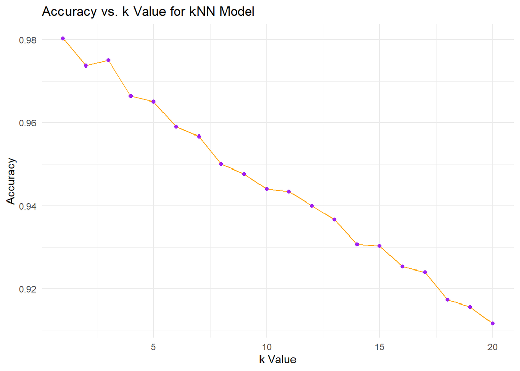

```r
k_values <- 1:20
accuracies <- sapply(k_values, function(k) {
  model <- knn(train = train_normalised, test = val_normalised, cl = train_labels, k = k)
  mean(model == val_normalised$Pay.result)
})

accuracy_data <- data.frame(k = k_values, Accuracy = accuracies)

ggplot(accuracy_data, aes(x = k, y = Accuracy)) +
  geom_line(color = "orange") +
  geom_point(color = "purple") +
  theme_minimal() +
  ggtitle("Accuracy vs. k Value for kNN Model") +
  xlab("k Value") +
  ylab("Accuracy")
```

*Fig 5. Accuracy vs k value for kNN models*

I started the first KNN model with a high k.

```r
first_knn <- knn(train = train_normalised, test = val_normalised, cl = train_labels, k=27)

conf_matrix_knn<- caret::confusionMatrix(first_knn, val_normalised$Pay.result)
print(conf_matrix_knn)
```

```
## Confusion Matrix and Statistics
##
##           Reference
## Prediction    0    1
##          0 2324  286
##          1   20  370
##
##                Accuracy : 0.898
##                  95% CI : (0.8866, 0.9086)
##     No Information Rate : 0.7813
##     P-Value [Acc > NIR] : < 0.00000000000000022
##
##                   Kappa : 0.6505
##
##  Mcnemar's Test P-Value : < 0.00000000000000022
##
##             Sensitivity : 0.9915
##             Specificity : 0.5640
##          Pos Pred Value : 0.8904
##          Neg Pred Value : 0.9487
##              Prevalence : 0.7813
##          Detection Rate : 0.7747
##    Detection Prevalence : 0.8700
##       Balanced Accuracy : 0.7777
##
##        'Positive' Class : 0
##
```

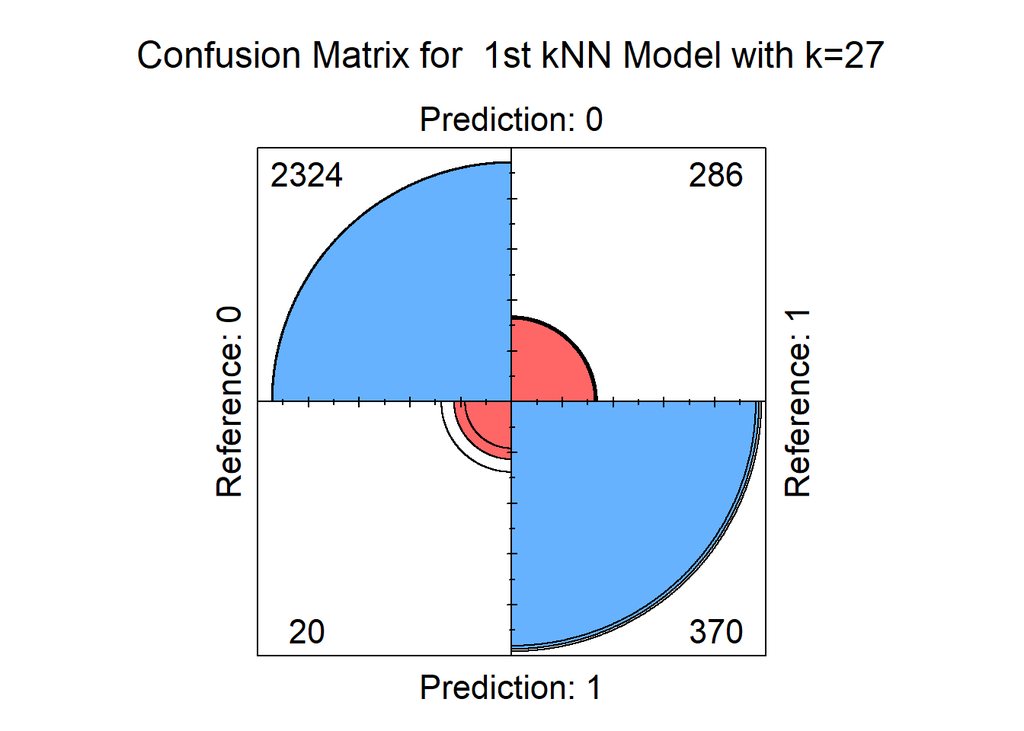

```r
fourfoldplot(conf_matrix_knn$table, color = c("#FF6666", "#66B2FF"),
             conf.level = 0.95, margin = 1, main = "Confusion Matrix for  1st kNN Model with k=27")
```

*Fig 6. Confusion matrix for 1st kNN model where k=27*

The baseline for the first KNN is an accuracy of 89% for both classes, and sensitivity of 99% but with a very low specificity of 56%. The aim is to improve this in the upcoming models.

```r
second_knn <- knn(train = train_normalised, test = val_normalised, cl = train_labels, k=3)


conf_matrix_knn2<- caret::confusionMatrix(second_knn, val_normalised$Pay.result)
print(conf_matrix_knn2)
```

```
## Confusion Matrix and Statistics
##
##           Reference
## Prediction    0    1
##          0 2330   61
##          1   14  595
##
##                Accuracy : 0.975
##                  95% CI : (0.9688, 0.9803)
##     No Information Rate : 0.7813
##     P-Value [Acc > NIR] : < 0.00000000000000022
##
##                   Kappa : 0.9249
##
##  Mcnemar's Test P-Value : 0.0000001087
##
##             Sensitivity : 0.9940
##             Specificity : 0.9070
##          Pos Pred Value : 0.9745
##          Neg Pred Value : 0.9770
##              Prevalence : 0.7813
##          Detection Rate : 0.7767
##    Detection Prevalence : 0.7970
##       Balanced Accuracy : 0.9505
##
##        'Positive' Class : 0
##
```

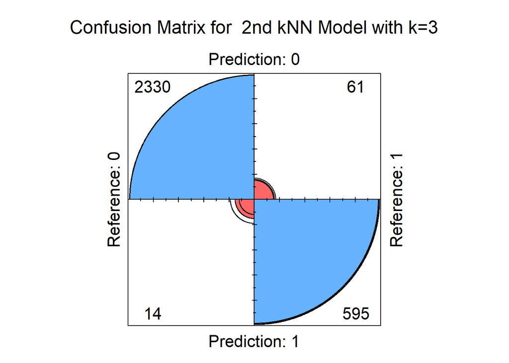

```r
fourfoldplot(conf_matrix_knn2$table, color = c("#FF6666", "#66B2FF"),
             conf.level = 0.95, margin = 1, main = "Confusion Matrix for  2nd kNN Model with k=3")
```

```r
#second KNN=3 has better result // accuracy = 0.97 // sensitivity = 0.99 // specificity = 0.90
```

*Fig 7. Confusion matrix k=3*

There is an immediate improvement when k=3, with now a specificity of 90%. From now on, this will be the model to beat.

```r
third_knn <- knn(train = train_normalised, test = val_normalised, cl = train_labels, k=8)


conf_matrix_knn3<- caret::confusionMatrix(third_knn, val_normalised$Pay.result)
print(conf_matrix_knn3)
```

```
## Confusion Matrix and Statistics
##
##           Reference
## Prediction    0    1
##          0 2324  134
##          1   20  522
##
##                Accuracy : 0.9487
##                  95% CI : (0.9402, 0.9563)
##     No Information Rate : 0.7813
##     P-Value [Acc > NIR] : < 0.00000000000000022
##
##                   Kappa : 0.8397
##
##  Mcnemar's Test P-Value : < 0.00000000000000022
##
##             Sensitivity : 0.9915
##             Specificity : 0.7957
##          Pos Pred Value : 0.9455
##          Neg Pred Value : 0.9631
##              Prevalence : 0.7813
##          Detection Rate : 0.7747
##    Detection Prevalence : 0.8193
##       Balanced Accuracy : 0.8936
##
##        'Positive' Class : 0
##
```

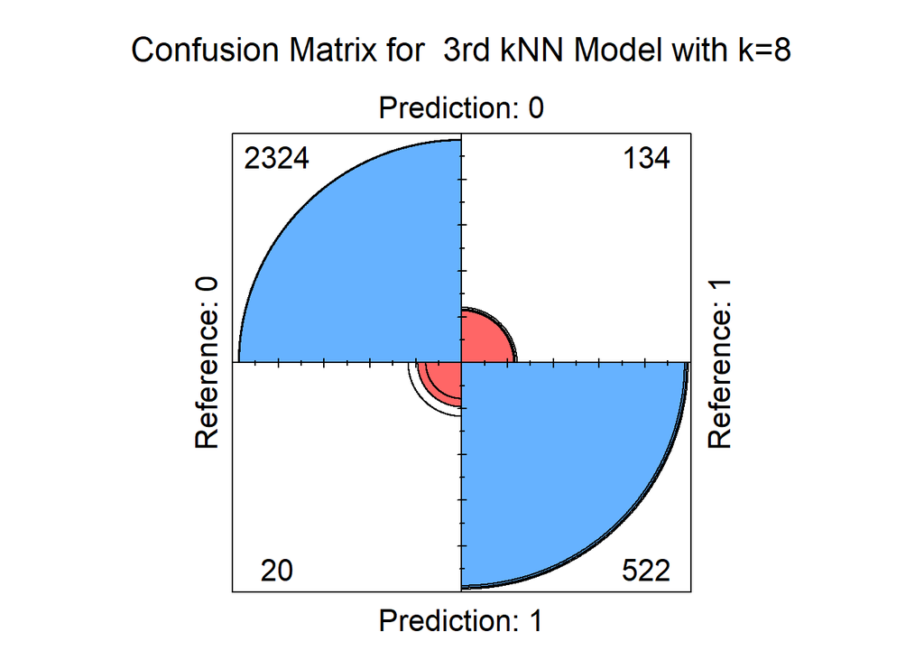

```r
fourfoldplot(conf_matrix_knn3$table, color = c("#FF6666", "#66B2FF"),
             conf.level = 0.95, margin = 1, main = "Confusion Matrix for  3rd kNN Model with k=8")
```

*Fig 8. Confusion matrix for kNN model where k=8*

With a k=8, a slight increase from the (so far) best model, the specificity has decreased to 79%, which means that the higher the k value, the lower the overall improvement of the model, which results in worse predictions.

```r
fourth_knn <- knn(train = train_normalised, test = val_normalised, cl = train_labels, k=9)

conf_matrix_knn4<- caret::confusionMatrix(fourth_knn, val_normalised$Pay.result)
print(conf_matrix_knn4)
```

```
## Confusion Matrix and Statistics
##
##           Reference
## Prediction    0    1
##          0 2326  140
##          1   18  516
##
##                Accuracy : 0.9473
##                  95% CI : (0.9387, 0.9551)
##     No Information Rate : 0.7813
##     P-Value [Acc > NIR] : < 0.00000000000000022
##
##                   Kappa : 0.8348
##
##  Mcnemar's Test P-Value : < 0.00000000000000022
##
##             Sensitivity : 0.9923
##             Specificity : 0.7866
##          Pos Pred Value : 0.9432
##          Neg Pred Value : 0.9663
##              Prevalence : 0.7813
##          Detection Rate : 0.7753
##    Detection Prevalence : 0.8220
##       Balanced Accuracy : 0.8895
##
##        'Positive' Class : 0
##
```

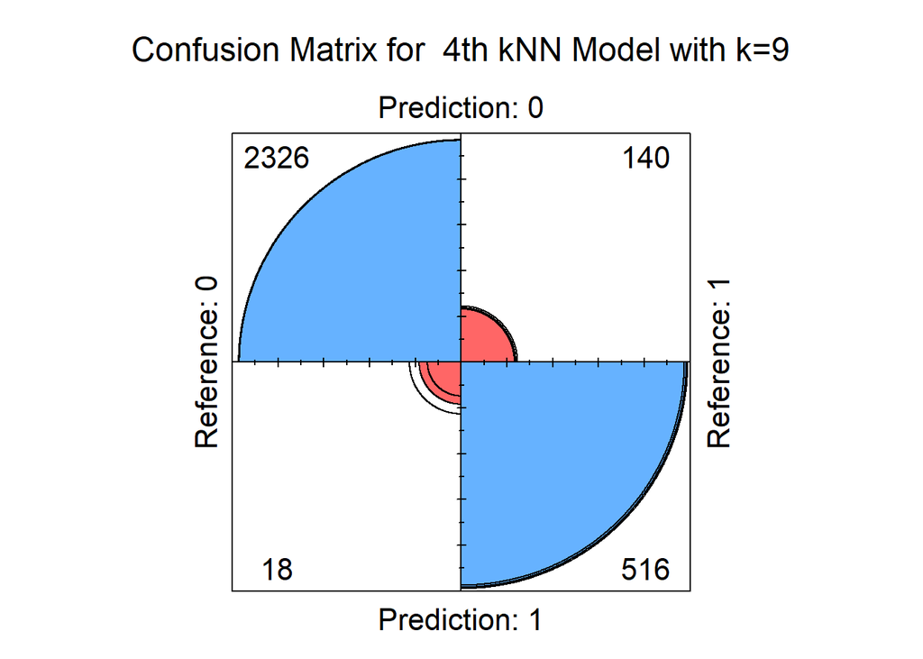

```r
fourfoldplot(conf_matrix_knn4$table, color = c("#FF6666", "#66B2FF"),
             conf.level = 0.95, margin = 1, main = "Confusion Matrix for  4th kNN Model with k=9")
```

*Fig 9. Confusion matrix for kNN model where k=9*

Even with a slight increase of k=9, this confirms for a final time that the higher the k value, the worse the predictions.

### Decision trees

The journey of the decision trees in this coursework has been interesting. I have computed a first decision tree with all of the variables available.

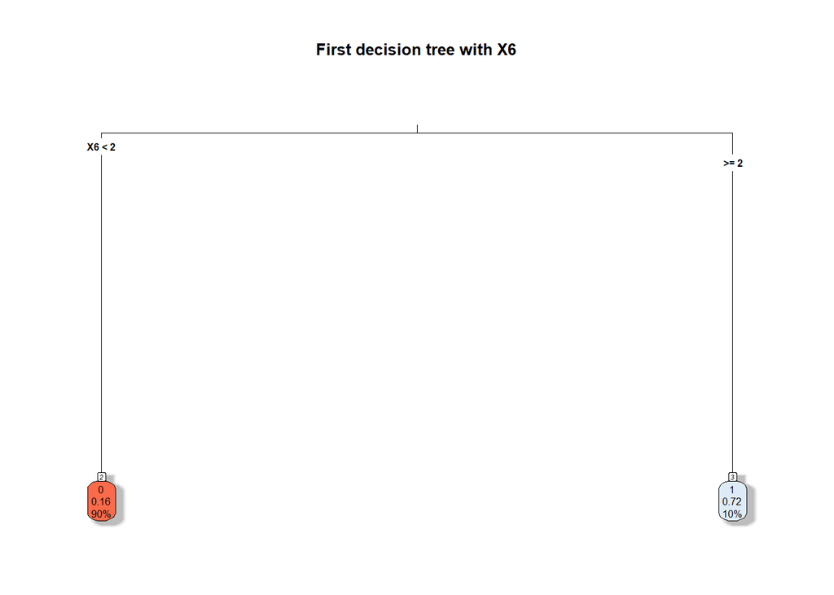

```r
dt_withX6 <- rpart(
  Pay.result ~ Credit.value + X2 + X3 + X4 + X5 + X6+  X7 + X8 + X9 + X11 + X12 + X13 + X14 + X15 + X16 + X17 + X18 + X19 + X20 + X21 + X22 + X23,
  data = train_data,
  method = "class"
)

#plot(decisiontree1C,main="decision tree 1C")
#text(decisiontree1C)

par(mar = c(5, 4, 4, 2) + 0.1)

rpart.plot(dt_withX6,
           type = 3,
           box.palette = "RdBu",
           shadow.col = "gray",
           nn = TRUE,
           cex = 0.5,
           main = "First decision tree with X6")
```

```r
predict_decisiontree_withX6 <- predict(dt_withX6, newdata = val_data,type = "class")
```

*Fig 10. First decision tree with X6*

The initial result from a decision tree with all default parameters was just a binary X6 node with two branches. I added some control parameters to be able to see further down the tree.

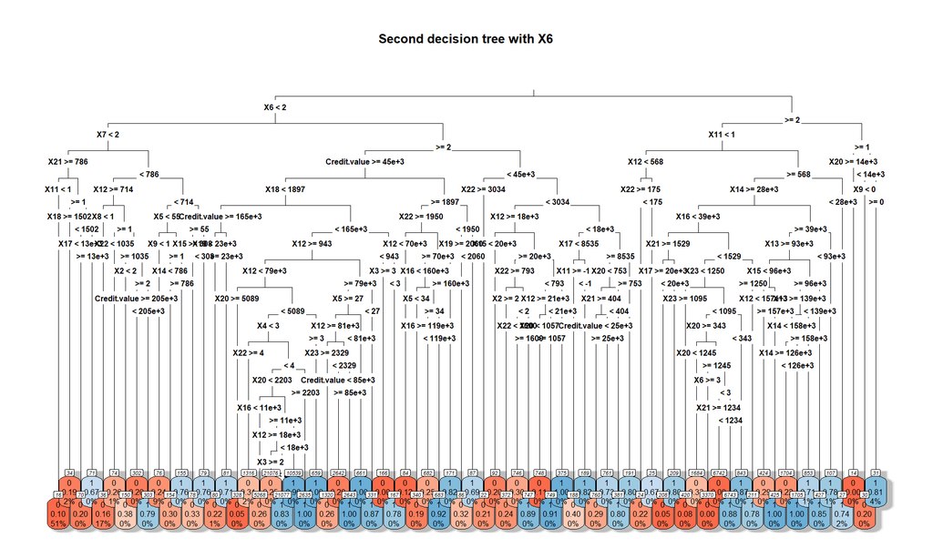

```r
dt_withX6_control <- rpart(
  Pay.result ~ Credit.value + X2 + X3 + X4 + X5 + X6+  X7 + X8 + X9 + X11 + X12 + X13 + X14 + X15 + X16 + X17 + X18 + X19 + X20 + X21 + X22 + X23,
  data = train_data,
  method = "class",
  control = rpart.control(
    cp = 0.001,
    minsplit = 10,
    maxdepth = 30
  )
)

par(mar = c(5, 4, 4, 2) + 0.1)

rpart.plot(dt_withX6_control,
           type = 3,
           box.palette = "RdBu",
           shadow.col = "gray",
           nn = TRUE,
           cex = 0.5,
           main = "Second decision tree with X6")
```

```r
predict_decisiontree_withX6_control <- predict(dt_withX6_control, newdata = val_data,type = "class")
```

*Fig 11. Second decision tree with X6*

The result was a tree so big that could not fit into the report properly without overlapping text and labels, regardless of the panel and text size. I noticed that X6 is at the top of three tree and therefore, I decided to do another tree without X6, to see the result.

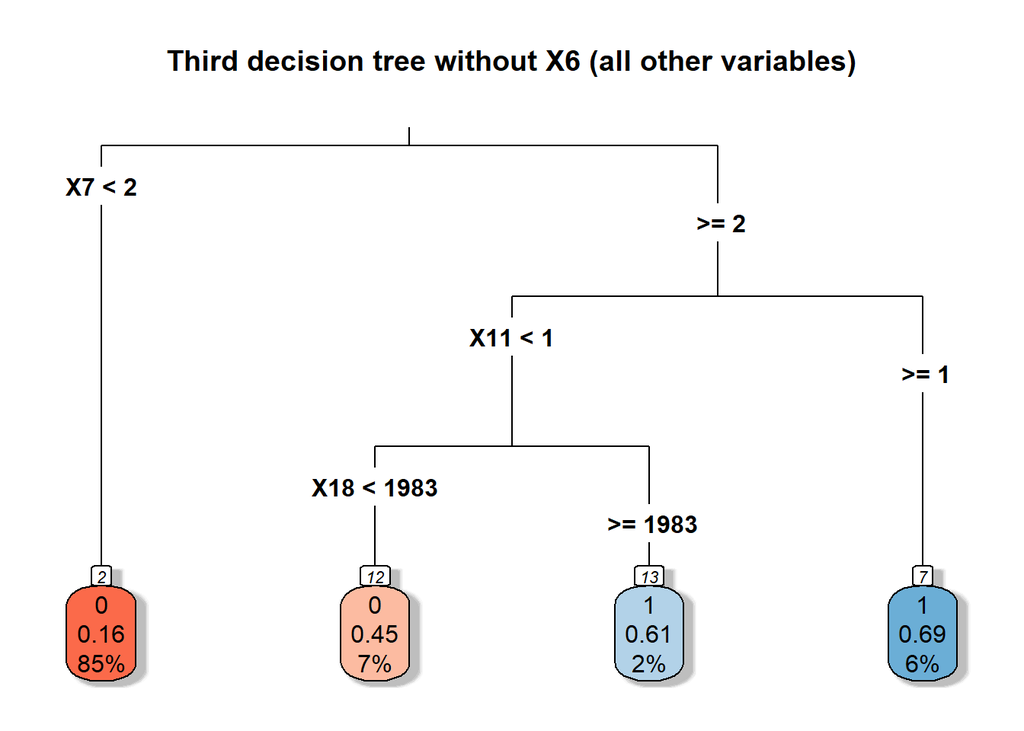

```r
decisiontree_noX6 <- rpart(
  Pay.result ~ Credit.value + X2 + X3 + X4 + X5 +  X7 + X8 + X9 + X11 + X12 + X13 + X14 + X15 + X16 + X17 + X18 + X19 + X20 + X21 + X22 + X23,
  data = train_data,
  method = "class"
  )

rpart.plot(decisiontree_noX6,
           type = 3,
           box.palette = "RdBu",
           shadow.col = "gray",
           nn = TRUE,
           cex = 1,
           main = "Third decision tree without X6 (all other variables)")
```

```r
#predictions for basic decision tree
predict_decisiontree_noX6 <- predict(decisiontree_noX6, newdata = val_data,type = "class")
```

*Fig 12. Third decision tree without X6*

I also created a confusion matrix for the pruned tree, once the model seemed to fit data well enough.

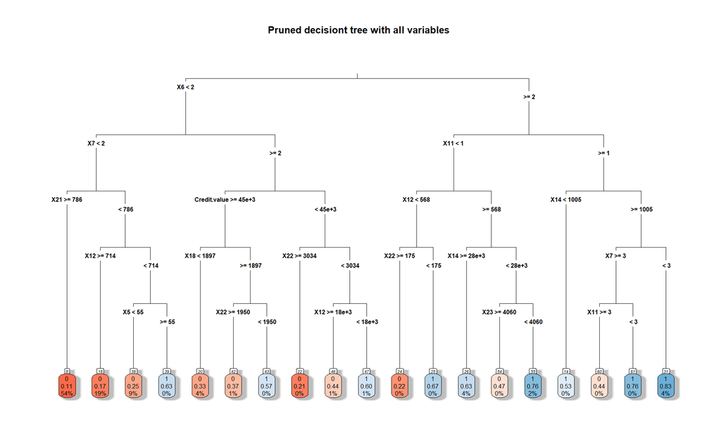

```r
dt_pruned <- rpart(
  Pay.result ~ Credit.value + X2 + X3 + X4 + X5 + X6+  X7 + X8 + X9 + X11 + X12 + X13 + X14 + X15 + X16 + X17 + X18 + X19 + X20 + X21 + X22 + X23,
  data = train_data,
  method = "class",
  control = rpart.control(
    cp = 0.0001,
    minsplit = 30,
    maxdepth = 5
  )
)

#plot(dt_pruned)
#text(dt_pruned)

rpart.plot(dt_pruned,
           type = 3,
           box.palette = "RdBu",
           shadow.col = "gray",
           nn = TRUE,
           cex = 0.5,
           main = "Pruned decisiont tree with all variables ")
```

```r
#predictions for pruned tree
predict_dt_pruned <- predict(dt_pruned, newdata = val_data, type = "class")

cm_dt_pruned <- confusionMatrix(predict_dt_pruned, val_data$Pay.result)
print(cm_dt_pruned)
```

```
## Confusion Matrix and Statistics
##
##           Reference
## Prediction    0    1
##          0 2218  431
##          1  126  225
##
##                Accuracy : 0.8143
##                  95% CI : (0.7999, 0.8281)
##     No Information Rate : 0.7813
##     P-Value [Acc > NIR] : 0.000004686
##
##                   Kappa : 0.3474
##
##  Mcnemar's Test P-Value : < 0.00000000000000022
##
##             Sensitivity : 0.9462
##             Specificity : 0.3430
##          Pos Pred Value : 0.8373
##          Neg Pred Value : 0.6410
##              Prevalence : 0.7813
##          Detection Rate : 0.7393
##    Detection Prevalence : 0.8830
##       Balanced Accuracy : 0.6446
##
##        'Positive' Class : 0
##
```

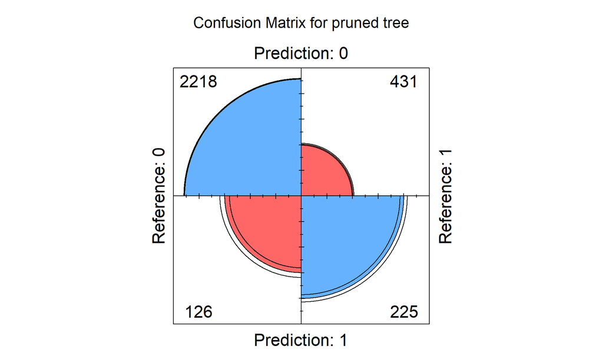

```r
fourfoldplot(cm_dt_pruned$table, color = c("#FF6666", "#66B2FF"),
             conf.level = 0.95, margin = 1, main = "Confusion Matrix for pruned tree")
```

*Fig 13. Pruned decision tree with all variables*

The pruned decision tree has an accuracy of 81%, sensitivity of 94% and a specificity of 34%. Even though the latter is quite low, I will keep track of the same metrics throughout the coursework, in order to identify the best model.

In the case of the pruned tree, it correctly predicted 2218 values of 0 and got wrong 431. It also correctly predicted 225 values of 1, and got wrong 126.

### Decision tree grid search

As mentioned in the methodology, some of the models have grid searches to find the best fit or the best parameters. This grid search for decision trees has a max depth of 10 models and uses the bootstrap method.

```r
#grid search

paramGrid <- expand.grid(
  maxdepth=c(1:10)
)

train_control_dt <- trainControl(
  method = "boot",
  number = 5,
  search = "grid"  # use the grid you declared above
)

model_gs_trees <- train(
  Pay.result ~ .,
  data = train_data,
  method = "rpart2",
  trControl = train_control_dt,
  tuneGrid = paramGrid
)

print(model_gs_trees)
```

```
## CART
##
## 12000 samples
##    23 predictor
##     2 classes: '0', '1'
##
## No pre-processing
## Resampling: Bootstrapped (5 reps)
## Summary of sample sizes: 12000, 12000, 12000, 12000, 12000
## Resampling results across tuning parameters:
##
##   maxdepth  Accuracy   Kappa
##    1        0.8240536  0.3620379
##    2        0.8240536  0.3620379
##    3        0.8240536  0.3620379
##    4        0.8240536  0.3620379
##    5        0.8240536  0.3620379
##    6        0.8240536  0.3620379
##    7        0.8240536  0.3620379
##    8        0.8240536  0.3620379
##    9        0.8240536  0.3620379
##   10        0.8240536  0.3620379
##
## Accuracy was used to select the optimal model using the largest value.
## The final value used for the model was maxdepth = 1.
```

The train control function stores all the parameters necessary, including the bootstrapping samples method, and the search method for grids.

The result of the best model was number 1, with an accuracy of 82%.

### Bagging

The first bagging model started off with only 10 trees, with the aim of increasing the number as I go along. It has a min split of 2 and a cp of 0.1.

```r
bag1 <- bagging(data = train_data,
                formula = Pay.result ~ .,
                nbagg = 10,
                coob = TRUE,
                control = rpart.control(minsplit = 2, cp = 0.1))


predict_bag1 <- predict(bag1, newdata = val_data,type = "class")


conf_matrix_predict_bag1 <- confusionMatrix(predict_bag1, val_data$Pay.result)
print(conf_matrix_predict_bag1)
```

```
## Confusion Matrix and Statistics
##
##           Reference
## Prediction    0    1
##          0 2245  459
##          1   99  197
##
##                Accuracy : 0.814
##                  95% CI : (0.7996, 0.8278)
##     No Information Rate : 0.7813
##     P-Value [Acc > NIR] : 0.000005794
##
##                   Kappa : 0.3216
##
##  Mcnemar's Test P-Value : < 0.00000000000000022
##
##             Sensitivity : 0.9578
##             Specificity : 0.3003
##          Pos Pred Value : 0.8303
##          Neg Pred Value : 0.6655
##              Prevalence : 0.7813
##          Detection Rate : 0.7483
##    Detection Prevalence : 0.9013
##       Balanced Accuracy : 0.6290
##
##        'Positive' Class : 0
##
```

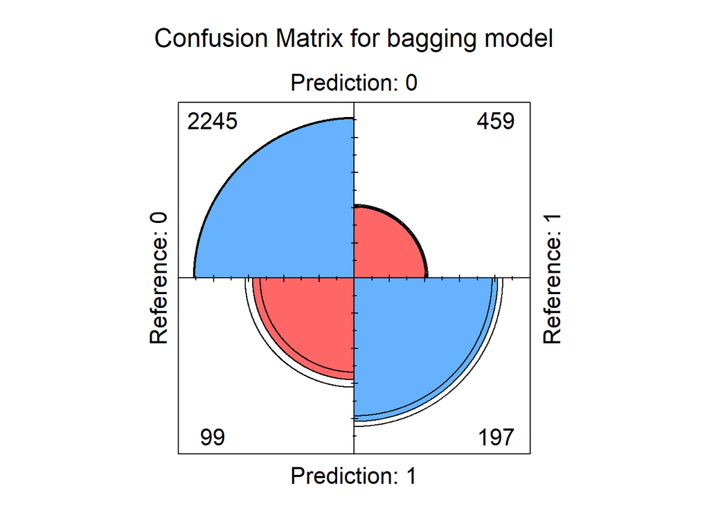

```r
fourfoldplot(conf_matrix_predict_bag1$table, color = c("#FF6666", "#66B2FF"),
             conf.level = 0.95, margin = 1, main = "Confusion Matrix for bagging model")
```

*Fig 14. Confusion matrix for bagging model*

The first bagging model has achieved an overall accuracy of 81% with sensitivity of 95% and a specificity of 30%, which is severely low compared with the rest of the models performed so far.

```r
bag2 <- bagging(data = train_data,
                formula = Pay.result ~ .,
                nbagg = 100,
                coob = TRUE,
                control = rpart.control(minsplit = 3, cp = 0.01))


predict_bag2 <- predict(bag2, newdata = val_data,type = "class")
predict_bag2
```

[output not shown]

[output cut: 68 more lines]

```r
conf_matrix_predict_bag2 <- confusionMatrix(predict_bag2, val_data$Pay.result)
print(conf_matrix_predict_bag2)
```

```
## Confusion Matrix and Statistics
##
##           Reference
## Prediction    0    1
##          0 2245  459
##          1   99  197
##
##                Accuracy : 0.814
##                  95% CI : (0.7996, 0.8278)
##     No Information Rate : 0.7813
##     P-Value [Acc > NIR] : 0.000005794
##
##                   Kappa : 0.3216
##
##  Mcnemar's Test P-Value : < 0.00000000000000022
##
##             Sensitivity : 0.9578
##             Specificity : 0.3003
##          Pos Pred Value : 0.8303
##          Neg Pred Value : 0.6655
##              Prevalence : 0.7813
##          Detection Rate : 0.7483
##    Detection Prevalence : 0.9013
##       Balanced Accuracy : 0.6290
##
##        'Positive' Class : 0
##
```

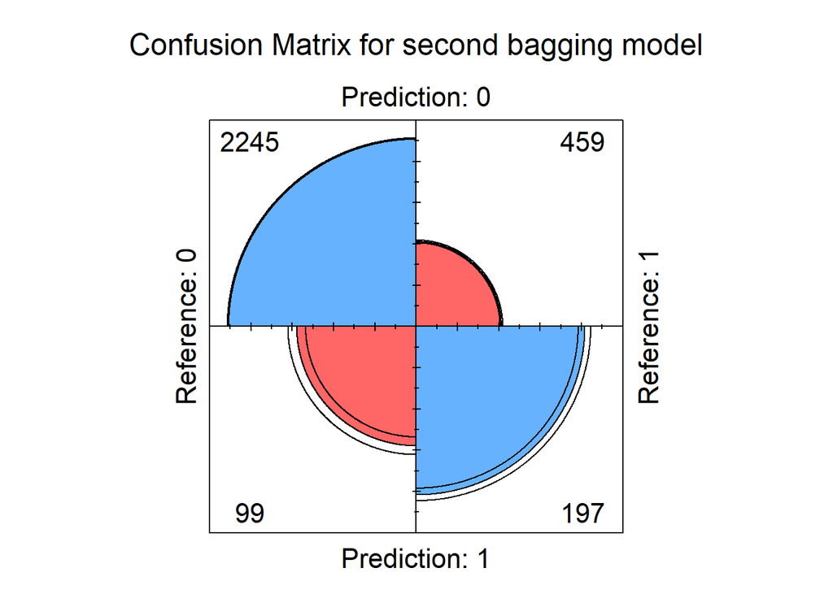

```r
fourfoldplot(conf_matrix_predict_bag2$table, color = c("#FF6666", "#66B2FF"),
             conf.level = 0.95, margin = 1, main = "Confusion Matrix for second bagging model")
```

*Fig 15. Confusion Matrix for second bagging model*

The second bagging model, that had 100 trees instead of 10, performed exactly the same as the first model. This takes bagging out of the race for the best model overall.

### Random forests

```r
rf_1 <- randomForest(Pay.result~., data=train_data, proximity=TRUE)

predictions_rf_1<-predict(rf_1, val_data)

rf_1_confusionMatrix<-confusionMatrix(predictions_rf_1, val_data$Pay.result)

rf_1_confusionMatrix
```

```
## Confusion Matrix and Statistics
##
##           Reference
## Prediction    0    1
##          0 2225  438
##          1  119  218
##
##                Accuracy : 0.8143
##                  95% CI : (0.7999, 0.8281)
##     No Information Rate : 0.7813
##     P-Value [Acc > NIR] : 0.000004686
##
##                   Kappa : 0.3413
##
##  Mcnemar's Test P-Value : < 0.00000000000000022
##
##             Sensitivity : 0.9492
##             Specificity : 0.3323
##          Pos Pred Value : 0.8355
##          Neg Pred Value : 0.6469
##              Prevalence : 0.7813
##          Detection Rate : 0.7417
##    Detection Prevalence : 0.8877
##       Balanced Accuracy : 0.6408
##
##        'Positive' Class : 0
##
```

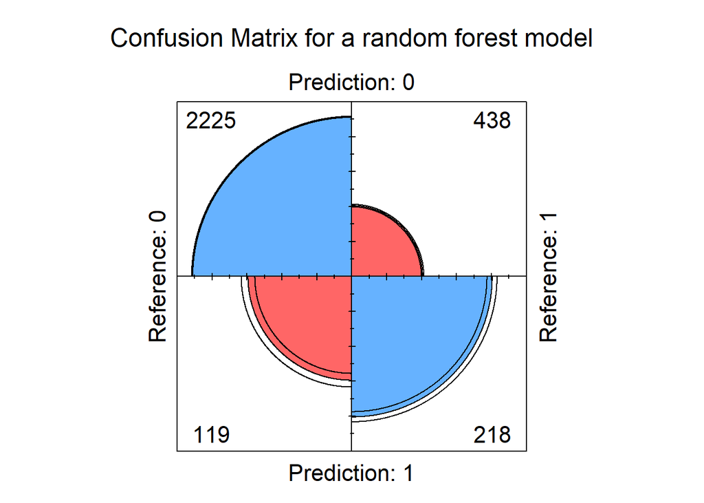

```r
fourfoldplot(rf_1_confusionMatrix$table, color = c("#FF6666", "#66B2FF"),
             conf.level = 0.95, margin = 1, main = "Confusion Matrix for a random forest model")
```

*Fig 16. Confusion Matrix for default random forest*

The random forest model performed slightly better than the bagging models, however not good enough to be able to be considered for best model. It obtained a 81% overall accuracy, with 94% sensitivity and only 33% specificity.

```r
importance <- randomForest::importance(rf_1)
print(importance)
```

```
##              MeanDecreaseGini
## Credit.value        211.85989
## X2                   44.23567
## X3                   76.59773
## X4                   55.37412
## X5                  235.65515
## X6                  429.30956
## X7                  195.94023
## X8                  104.41586
## X9                   99.95795
## X10                 101.76076
## X11                  75.09521
## X12                 242.68758
## X13                 220.87068
## X14                 211.27958
## X15                 204.31396
## X16                 203.28595
## X17                 201.71640
## X18                 208.12669
## X19                 197.33722
## X20                 188.02608
## X21                 182.18060
## X22                 177.49259
## X23                 183.26768
```

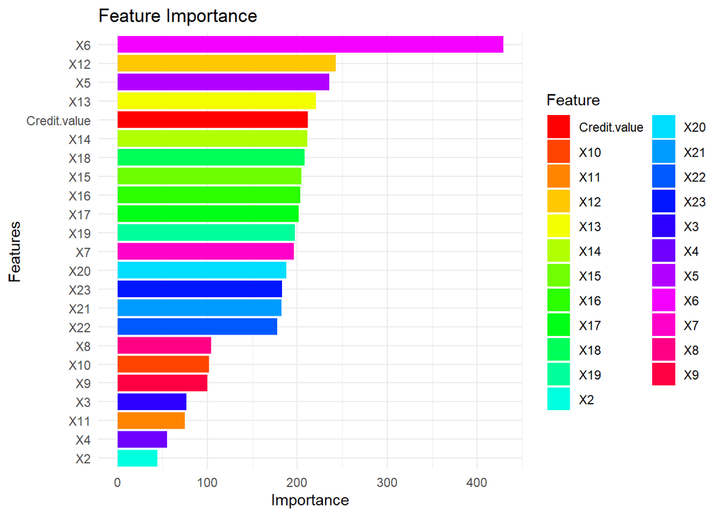

```r
importance_df <- as.data.frame(importance)
importance_df$Feature <- rownames(importance_df)


ggplot(importance_df, aes(x=reorder(Feature, MeanDecreaseGini), y=MeanDecreaseGini, fill=Feature)) +
  geom_bar(stat="identity") +
  scale_fill_manual(values=rainbow(n=length(unique(importance_df$Feature)))) +
  theme_minimal() +
  labs(title="Feature Importance", x="Features", y="Importance") +
  coord_flip()
```

*Fig 17. Feature importance performed by RF model*

The first few most important variables will be used in the gradient boosting models, in order to save the computational power and see if there is any overall improvement to the accuracy of the models.

#### Random forest grid search

The RF grid search has 4 cycles represented by mtry as a parameter grid. It also uses the bootstrap method, and 100 trees.

```r
mtry <- c(3, 5, 10, 16)

paramGrid_rf <- expand.grid(
  mtry = mtry
)


train_control_rf <- trainControl(
  method = "boot",
  number = 5,
  search = "grid"
)


model_gs_rf <- train(
  Pay.result ~ .,
  data = train_data,
  method = "rf",
  trControl = train_control_rf,
  tuneGrid = paramGrid_rf,
  ntree = 100
)

predictions_gridSearch_rf<-predict(model_gs_rf, val_data)

gridSearch_confusionMatrix_rf<-confusionMatrix(predictions_gridSearch_rf, val_data$Pay.result)

gridSearch_confusionMatrix_rf
```

```
## Confusion Matrix and Statistics
##
##           Reference
## Prediction    0    1
##          0 2228  432
##          1  116  224
##
##                Accuracy : 0.8173
##                  95% CI : (0.803, 0.831)
##     No Information Rate : 0.7813
##     P-Value [Acc > NIR] : 0.000000631
##
##                   Kappa : 0.3532
##
##  Mcnemar's Test P-Value : < 0.00000000000000022
##
##             Sensitivity : 0.9505
##             Specificity : 0.3415
##          Pos Pred Value : 0.8376
##          Neg Pred Value : 0.6588
##              Prevalence : 0.7813
##          Detection Rate : 0.7427
##    Detection Prevalence : 0.8867
##       Balanced Accuracy : 0.6460
##
##        'Positive' Class : 0
##
```

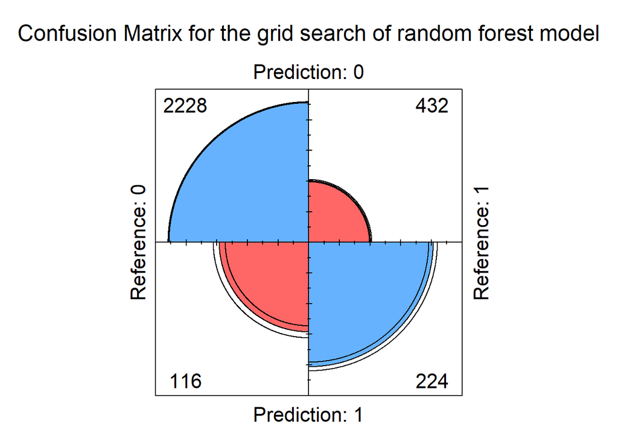

```r
fourfoldplot(gridSearch_confusionMatrix_rf$table, color = c("#FF6666", "#66B2FF"),
             conf.level = 0.95, margin = 1, main = "Confusion Matrix for the grid search of random forest model")
```

*Fig 17. Confusion Matrix for the grid search of a random forest model*

The grid search for this model did not perform any better than before. It had an accuracy of 0.81, sensitivity of 0.94, and specificity of 0.33. This also means that it is no longer considered in the running for the best model.

### Gradient boosting

As mentioned before, on of the gradient boosting models performed below will include only the first few most important features in the dataset.

The first model is a baseline model where Pay.result is twiddled with the rest of the variables, in order to get a better understanding of the computational power it uses but also to get the accuracy.

```r
train_data$Pay.result <- as.character(train_data$Pay.result)


gbm_1 <- gbm(data=train_data, Pay.result~., distribution = "bernoulli")


predict_gbm<-predict(gbm_1, val_data, type="response", n.trees = 100)
predict_gbm <- ifelse(predict_gbm > 0.5, 1, 0)
predict_gbm <- as.factor(predict_gbm)

nrow(val_data)
```

```
## [1] 3000
```

```r
length(predict_gbm)
```

```
## [1] 3000
```

```r
gbm_confusionMatrix<-confusionMatrix(predict_gbm, val_data$Pay.result)

length(val_data)
```

```
## [1] 24
```

```r
length(predict_gbm)
```

```
## [1] 3000
```

```r
gbm_confusionMatrix
```

```
## Confusion Matrix and Statistics
##
##           Reference
## Prediction    0    1
##          0 2234  454
##          1  110  202
##
##                Accuracy : 0.812
##                  95% CI : (0.7976, 0.8258)
##     No Information Rate : 0.7813
##     P-Value [Acc > NIR] : 0.00001979
##
##                   Kappa : 0.3218
##
##  Mcnemar's Test P-Value : < 0.00000000000000022
##
##             Sensitivity : 0.9531
##             Specificity : 0.3079
##          Pos Pred Value : 0.8311
##          Neg Pred Value : 0.6474
##              Prevalence : 0.7813
##          Detection Rate : 0.7447
##    Detection Prevalence : 0.8960
##       Balanced Accuracy : 0.6305
##
##        'Positive' Class : 0
##
```

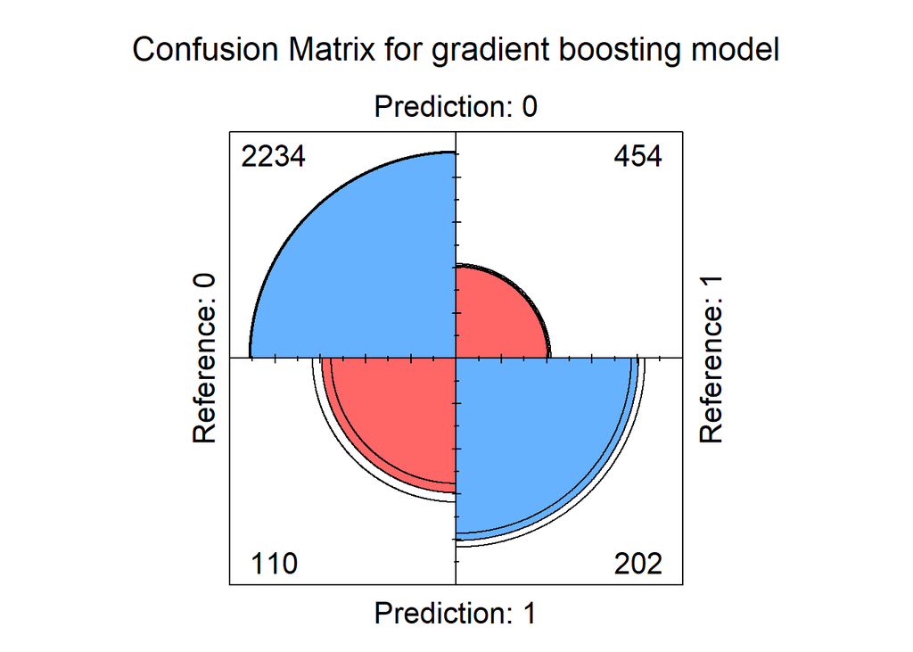

```r
fourfoldplot(gbm_confusionMatrix$table, color = c("#FF6666", "#66B2FF"),
             conf.level = 0.95, margin = 1, main = "Confusion Matrix for gradient boosting model")
```

*Fig 18. Confusion matrix for gradient boosting model with all variables*

The model did not perform that well, considering it only got an accuracy of 81%, sensitivity of 95% and a specificity of 30%.

```r
train_data$Pay.result <- as.character(train_data$Pay.result)


gbm_2 <- gbm(data=train_data, Pay.result~ X6 + X12+ X5+ X13+X18+X14+X16+X15+X17+X19, distribution = "bernoulli")


predict_gbm2<-predict(gbm_2, val_data, type="response", n.trees = 100)
predict_gbm2 <- ifelse(predict_gbm2 > 0.5, 1, 0)
predict_gbm2 <- as.factor(predict_gbm2)

nrow(val_data)
```

```
## [1] 3000
```

```r
length(predict_gbm)
```

```
## [1] 3000
```

```r
gbm_confusionMatrix2<-confusionMatrix(predict_gbm2, val_data$Pay.result)

length(val_data)
```

```
## [1] 24
```

```r
length(predict_gbm)
```

```
## [1] 3000
```

```r
gbm_confusionMatrix2
```

```
## Confusion Matrix and Statistics
##
##           Reference
## Prediction    0    1
##          0 2245  459
##          1   99  197
##
##                Accuracy : 0.814
##                  95% CI : (0.7996, 0.8278)
##     No Information Rate : 0.7813
##     P-Value [Acc > NIR] : 0.000005794
##
##                   Kappa : 0.3216
##
##  Mcnemar's Test P-Value : < 0.00000000000000022
##
##             Sensitivity : 0.9578
##             Specificity : 0.3003
##          Pos Pred Value : 0.8303
##          Neg Pred Value : 0.6655
##              Prevalence : 0.7813
##          Detection Rate : 0.7483
##    Detection Prevalence : 0.9013
##       Balanced Accuracy : 0.6290
##
##        'Positive' Class : 0
##
```

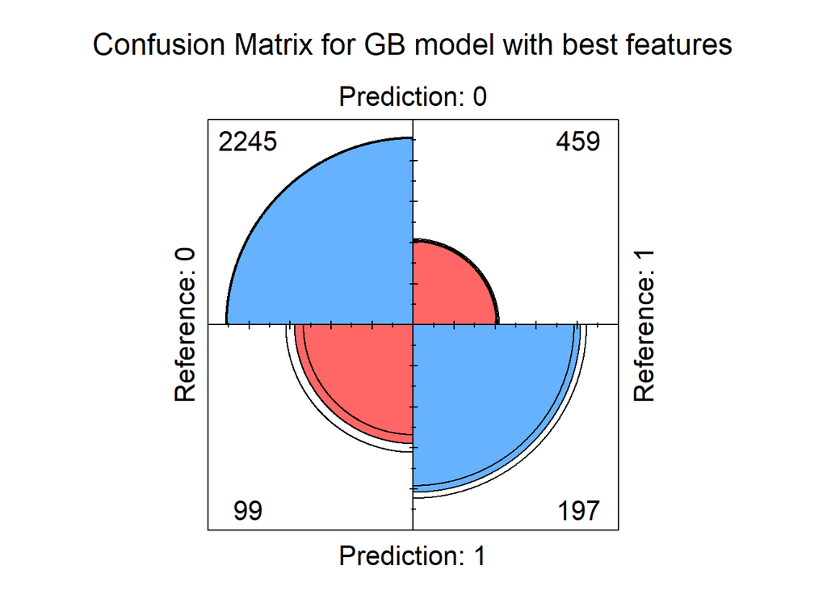

```r
fourfoldplot(gbm_confusionMatrix2$table, color = c("#FF6666", "#66B2FF"),
             conf.level = 0.95, margin = 1, main = "Confusion Matrix for GB model with best features")
```

Unfortunately, the variable selection did not perform any better in terms of accuracy, but it has performed better computationally.

#### Gradient boosting grid search

The gradient boosting grid search has a more extensive parameter grid list, including max depth, samples by tree, and nrounds. It uses the cross-validation method.

```r
paramGrid_gbm2 <- expand.grid(nrounds = c(100,200),
                              max_depth = c(10, 15, 20, 25),
                              colsample_bytree = seq(0.5, 0.9, length.out = 5),
                              eta = 0.1,
                              gamma=0,
                              min_child_weight = 1,
                              subsample = 1
)

train_control_gbm <- trainControl(
  method = "cv",
  number = 10,
  search = "grid"
)

gbm2 <- train(Pay.result ~. , data = train_data, method = "xgbTree",
              tuneGrid = paramGrid_gbm2, trControl=train_control_gbm)
```

[output not shown]

[output cut: 145 more lines]

[output not shown]

```r
predictions_gridSearch_gbm<-predict(gbm2, val_data)

gridSearch_confusionMatrix_gbm<-confusionMatrix(predictions_gridSearch_gbm, val_data$Pay.result)

gridSearch_confusionMatrix_gbm
```

```
## Confusion Matrix and Statistics
##
##           Reference
## Prediction    0    1
##          0 2227  439
##          1  117  217
##
##                Accuracy : 0.8147
##                  95% CI : (0.8003, 0.8284)
##     No Information Rate : 0.7813
##     P-Value [Acc > NIR] : 0.000003783
##
##                   Kappa : 0.3412
##
##  Mcnemar's Test P-Value : < 0.00000000000000022
##
##             Sensitivity : 0.9501
##             Specificity : 0.3308
##          Pos Pred Value : 0.8353
##          Neg Pred Value : 0.6497
##              Prevalence : 0.7813
##          Detection Rate : 0.7423
##    Detection Prevalence : 0.8887
##       Balanced Accuracy : 0.6404
##
##        'Positive' Class : 0
##
```

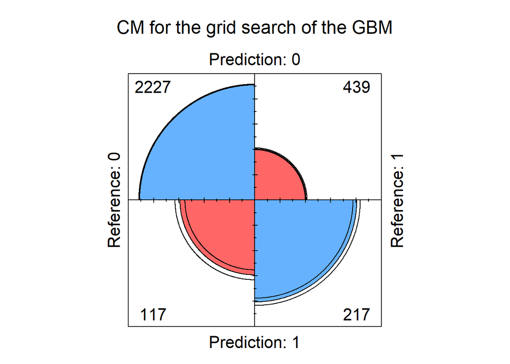

```r
fourfoldplot(gridSearch_confusionMatrix_gbm$table, color = c("#FF6666", "#66B2FF"),
             conf.level = 0.95, margin = 1, main = "CM for the grid search of the GBM")
```

*Fig 20. Confusion matrix of the grid search for the GBM*

## Data balancing

I chose to apply the oversampling method, often used for cases such as this one. It is defined by adding more copies to a minority class. Sometimes it is necessary to do data balancing, because some machine learning algorithms can be affected by a large disparity between the majority class and minority class and the fit of the model can suffer. The two classes do not need to be equal, but close in rows. (Vidhya, 2024)

The oversampling function include an N-desired which is represented by the number of samples you want to have in a balanced data set after the oversampling process, in this case 16000. Once the data is over sampled, it is stored into a new variable and label selection is performed.

After the pre-processing is done, I have applied the new data to the best KNN model.

```r
train_data %>% group_by(Pay.result) %>% summarise(n())
```

```
## # A tibble: 2 × 2
##   Pay.result `n()`
##   <chr>      <int>
## 1 0           9338
## 2 1           2662
```

```r
N_desired = 16000

train_data_oversampled <- ovun.sample(Pay.result ~ ., data = train_data, method = "over", N = N_desired)$data

train_data_oversampled %>% group_by(Pay.result) %>% summarise(n())
```

```
## # A tibble: 2 × 2
##   Pay.result `n()`
##   <chr>      <int>
## 1 0           9338
## 2 1           6662
```

```r
#extract new labels

train_labels_oversampled<-train_data_oversampled$Pay.result
```

```r
best_knn <- knn(train = train_data_oversampled, test = val_normalised, cl = train_labels_oversampled, k=3)


best_knn_cm<- caret::confusionMatrix(second_knn, val_normalised$Pay.result)
print(best_knn_cm)
```

```
## Confusion Matrix and Statistics
##
##           Reference
## Prediction    0    1
##          0 2330   61
##          1   14  595
##
##                Accuracy : 0.975
##                  95% CI : (0.9688, 0.9803)
##     No Information Rate : 0.7813
##     P-Value [Acc > NIR] : < 0.00000000000000022
##
##                   Kappa : 0.9249
##
##  Mcnemar's Test P-Value : 0.0000001087
##
##             Sensitivity : 0.9940
##             Specificity : 0.9070
##          Pos Pred Value : 0.9745
##          Neg Pred Value : 0.9770
##              Prevalence : 0.7813
##          Detection Rate : 0.7767
##    Detection Prevalence : 0.7970
##       Balanced Accuracy : 0.9505
##
##        'Positive' Class : 0
##
```

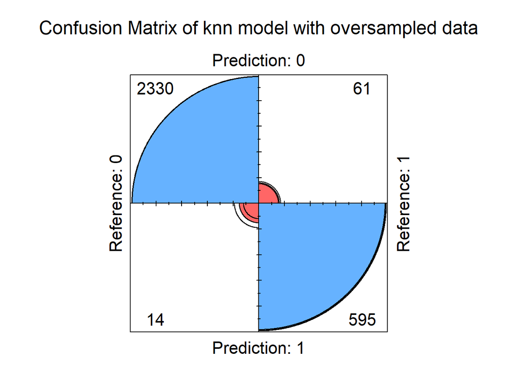

```r
fourfoldplot(best_knn_cm$table, color = c("#FF6666", "#66B2FF"),
             conf.level = 0.95, margin = 1, main = "Confusion Matrix of knn model with oversampled data")
```

## Best model

```r
best_knn_model <- knn(train = train_normalised, test = test_normalised, cl = train_labels, k=3)

cm_bestmodel_knn<- caret::confusionMatrix(best_knn_model, test_normalised$Pay.result)
print(cm_bestmodel_knn)
```

```
## Confusion Matrix and Statistics
##
##           Reference
## Prediction     0     1
##          0 11609   343
##          1    73  2975
##
##                Accuracy : 0.9723
##                  95% CI : (0.9695, 0.9748)
##     No Information Rate : 0.7788
##     P-Value [Acc > NIR] : < 0.00000000000000022
##
##                   Kappa : 0.9171
##
##  Mcnemar's Test P-Value : < 0.00000000000000022
##
##             Sensitivity : 0.9938
##             Specificity : 0.8966
##          Pos Pred Value : 0.9713
##          Neg Pred Value : 0.9760
##              Prevalence : 0.7788
##          Detection Rate : 0.7739
##    Detection Prevalence : 0.7968
##       Balanced Accuracy : 0.9452
##
##        'Positive' Class : 0
##
```

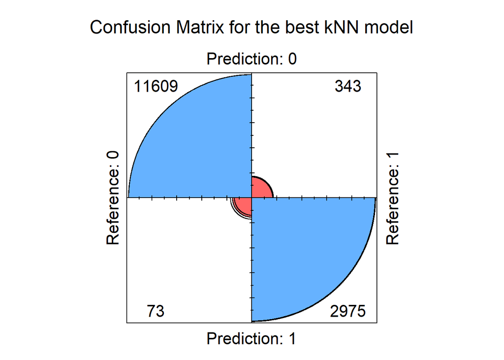

```r
fourfoldplot(cm_bestmodel_knn$table, color = c("#FF6666", "#66B2FF"),
             conf.level = 0.95, margin = 1, main = "Confusion Matrix for the best kNN model")
```

*Fig 22. CM for best kNN model*

The kNN model performed really well on unseen data, with accuracy of 97%, sensitivity of 99% and specificity of 89%. There is a good balance between the three metrics, and therefore the model is not overfitting and is finding the correct patterns in data.

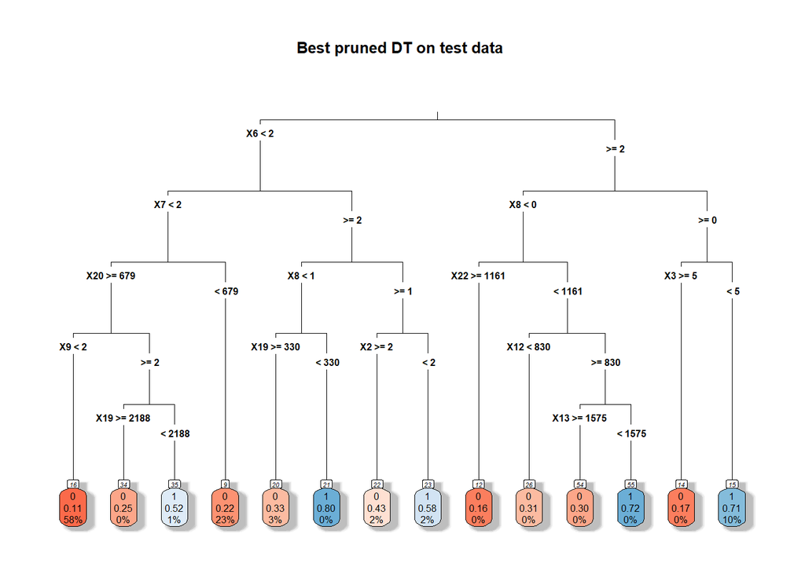

```r
dt_pruned_best <- rpart(
  Pay.result ~ Credit.value + X2 + X3 + X4 + X5 + X6+  X7 + X8 + X9 + X11 + X12 + X13 + X14 + X15 + X16 + X17 + X18 + X19 + X20 + X21 + X22 + X23,
  data = test_data,
  method = "class",
  control = rpart.control(
    cp = 0.0001,
    minsplit = 30,
    maxdepth = 5
  )
)

rpart.plot(dt_pruned_best,
           type = 3,
           box.palette = "RdBu",
           shadow.col = "gray",
           nn = TRUE,
           cex = 0.5,
           main = "Best pruned DT on test data ")
```

```r
predict_dt_pruned_best <- predict(dt_pruned_best, newdata = val_data, type = "class")

cm_dt_pruned_best <- confusionMatrix(predict_dt_pruned_best, val_data$Pay.result)
print(cm_dt_pruned_best)
```

```
## Confusion Matrix and Statistics
##
##           Reference
## Prediction    0    1
##          0 2212  429
##          1  132  227
##
##                Accuracy : 0.813
##                  95% CI : (0.7986, 0.8268)
##     No Information Rate : 0.7813
##     P-Value [Acc > NIR] : 0.00001081
##
##                   Kappa : 0.3462
##
##  Mcnemar's Test P-Value : < 0.00000000000000022
##
##             Sensitivity : 0.9437
##             Specificity : 0.3460
##          Pos Pred Value : 0.8376
##          Neg Pred Value : 0.6323
##              Prevalence : 0.7813
##          Detection Rate : 0.7373
##    Detection Prevalence : 0.8803
##       Balanced Accuracy : 0.6449
##
##        'Positive' Class : 0
##
```

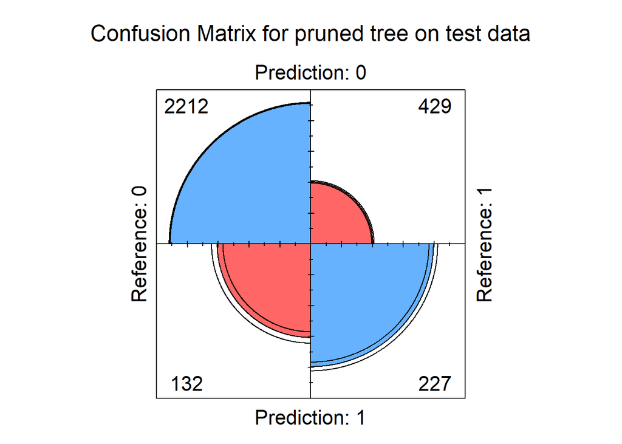

```r
fourfoldplot(cm_dt_pruned_best$table, color = c("#FF6666", "#66B2FF"),
             conf.level = 0.95, margin = 1, main = "Confusion Matrix for pruned tree on test data")
```

## Analysis and conclusion

This coursework uses confusion matrices, a performance measure for ML classifications, where the output is 2 or more classes (S., 2021). The specific output is a table of actual values and predicted values. It shows the number of predictions as a form of four:

- True positive -> predicted correctly (top left)
- True negative -> predicted correctly (bottom right)
- False negative -> predicted wrong (bottom left)
- False positive -> predicted wrong (top right), (S., 2021)

The confusion matrices also report the accuracy, sensitivity and specificity of a model, which is what this report has used to measure overall performance for comparison. Accuracy should always be high, ideally in the 90 range, however there will always be some sort of trade off between high accuracy and better sensitivity and specificity. Specificity is necessary because it measure the model’s ability to identify the negative instances. On the other hand, sensitivity measures the model’s ability to identify positive cases. (S., 2021)

There is a probable reason why the kNN model achieved the best results, and that being that it used normalized train and validation set, which made the data smoother and much easier to compute. The decision tree, even if pruned, used non-normalized sets. Even though normalization is not typically required for decision trees, it might be worth investigating if normalized train and validation sets would perform better. Normalized sets passed through pruned trees can help with the overall interpretability of the model, a domain that needs further research.

In conclusion, this report has looked at the comparison between multiple classification models in order to help predict defaulters in credit card risk. Even though most models, including the grid searchers achieved almost the same accuracy, sensitivity and specificity, kNN has proved to be the successful models that could be further used in credit card risk assessment. Beyond that, the report used p value variable selection and feature importance for random forest, that showcased the X6 as the dominant variable overall.

## References

Calculate sensitivity, specificity and predictive values in caret (2023) GeeksforGeeks. Available at: https://www.geeksforgeeks.org/calculate-sensitivity-specificity-and-predictive-values-in-caret/?ref=lbp (Accessed: 23 January 2024).

Confusion matrix in machine learning (2024) GeeksforGeeks. Available at: https://www.geeksforgeeks.org/confusion-matrix-machine-learning/ (Accessed: 26 January 2024).

Greenwell, B.B.& B. (2020) Hands-on machine learning with R, Chapter 12 Gradient Boosting. Available at: https://bradleyboehmke.github.io/HOML/gbm.html (Accessed: 23 January 2024).

Narkhede, S. (2021) Understanding confusion matrix, Medium. Available at: https://towardsdatascience.com/understanding-confusion-matrix-a9ad42dcfd62 (Accessed: 23 January 2024).

Saini, A. and Vidhya (2024) Gradient boosting algorithm: A complete guide for beginners, Analytics Vidhya. Available at: https://www.analyticsvidhya.com/blog/2021/09/gradient-boosting-algorithm-a-complete-guide-for-beginners/ (Accessed: 23 January 2024).

Shah, R. and Vidhya (2023) Tune hyperparameters with GRIDSEARCHCV, Analytics Vidhya. Available at: https://www.analyticsvidhya.com/blog/2021/06/tune-hyperparameters-with-gridsearchcv/ (Accessed: 23 January 2024).

Vidhya (2023) How does the gradient descent algorithm work in machine learning?, Analytics Vidhya. Available at: https://www.analyticsvidhya.com/blog/2020/10/how-does-the-gradient-descent-algorithm-work-in-machine-learning/#:~:text=Gradient%20descent%20is%20an%20iterative,function%20at%20the%20current%20point. (Accessed: 23 January 2024).

Vidhya (2024) 10 techniques to solve imbalanced classes in machine learning (updated 2024), Analytics Vidhya. Available at: https://www.analyticsvidhya.com/blog/2020/07/10-techniques-to-deal-with-class-imbalance-in-machine-learning/ (Accessed: 23 January 2024).

James, G. et al. (2022) An introduction to statistical learning: With applications in R. 2nd edn. Boston: Springer.